# Curation of motifs

Melanie (1028-02098-001-001)

February 06, 2026

# Introduction

The goal of this analysis is to:

1. Showcase motifs found by ChromBPNet and BPNet.
2. Collect and filter motifs found by ChromBPNet and BPNet.
3. Merge ChromBPNet and BPNet motifs into sets for downstream analysis.
4. Visualize motif summaries and representations.

# Computational Setup

```r
#Standard packages
library(rtracklayer) ; library(GenomicRanges); library(magrittr) ; library(Biostrings)
library(ggplot2) ; library(reshape2); library(plyranges); library(Rsamtools); library(parallel)
library(dplyr); library(data.table); library(patchwork); library(readr); library(testit)

#KNITR Options
setwd("/n/projects/mw2098/publications/2024_weilert_acc/code/2_analysis/")
figure_filepath<-"figures/5_curate_motifs"
options(knitr.figure_dir=figure_filepath, java.parameters = "- Xmx6g")

#Lab sources
source("scripts/r/granges_common.r")
source("scripts/r/metapeak_common.r")
source("scripts/r/knitr_common.r")
source("scripts/r/caching.r")
source("scripts/r/metapeak_functions.r")

#Specific sources
library(BSgenome.Mmusculus.UCSC.mm10)
library(TxDb.Mmusculus.UCSC.mm10.knownGene)
library(org.Mm.eg.db)
library(ggseqlogo)
source("scripts/r/motif_functions.r")

#Pre-existing variables
threads <- 5
dir.create('bed/mapped_motifs', recursive = T, showWarnings = F)
dir.create('tsv/mapped_motifs', recursive = T, showWarnings = F)
dir.create('rdata/mapped_motifs', recursive = T, showWarnings = F)
bsgenome<-BSgenome.Mmusculus.UCSC.mm10
txdb<-TxDb.Mmusculus.UCSC.mm10.knownGene

#model information
tasks<-c('oct4', 'sox2', 'nanog', 'klf4', 'zic3')
peaks.path<-'bed/bpreveal/bpnet_osknz_fold1_all.bed'
acc_counts_contrib.bw<-'shap/atac_wt_fold1_atac_counts.bw'
motif_to_task.list<-list('Oct4-Sox2' = 'oct4', 'Oct4' = 'oct4', 'Sox2' = 'sox2', 'Klf4' = 'klf4', 'Zic3' = 'zic3', 'Nanog' = 'nanog')
output_length <- 1000

#experimental data information
repeats.path<-'/n/projects/mw2098/genomes/mm10/repeatmasker.mm10.gr.rds'
nexus.bw.list<-list(zic3 = list(pos = 'bw/mesc_zic3_nexus_combined_normalized_positive.bw',
                                neg = 'bw/mesc_zic3_nexus_combined_normalized_negative.bw'),
                    oct4 = list(pos = 'bw/mesc_oct4_nexus_combined_normalized_positive.bw',
                                neg = 'bw/mesc_oct4_nexus_combined_normalized_negative.bw'),
                    sox2 = list(pos = 'bw/mesc_sox2_nexus_combined_normalized_positive.bw',
                                neg = 'bw/mesc_sox2_nexus_combined_normalized_negative.bw'),
                    klf4 = list(pos = 'bw/mesc_klf4_nexus_combined_normalized_positive.bw',
                                neg = 'bw/mesc_klf4_nexus_combined_normalized_negative.bw'),
                    nanog = list(pos = 'bw/mesc_nanog_nexus_combined_normalized_positive.bw',
                                 neg = 'bw/mesc_nanog_nexus_combined_normalized_negative.bw'))
atac_obs.bw<-'bw/mesc_native_atac_cutsites_combined.bw'
atac_frag.bw<-'bw/mesc_native_atac_combined.bw'
atac_pred.bw<-'preds/atac_wt_fold1_atac_atac_peaks_all.bw'
bias_seqlets.list<-list(counts = 'modiscolite/atac_bias_atac_counts/seqlets.tsv', profile = 'modiscolite/atac_bias_atac_profile/seqlets.tsv')
bg_freqs<-c(.2, .3, .3, .2)
input_length<-2032
```

# Define seqlets

Use fold1 as the template, define all seqlets with n>100 instances mapped based on the identities of fold1. There are other weak motifs found in the folds with n<100, but they have been found to be previously not very impactful on accessibility according to our models and are not the key focus of our work. Please reference the `modiscolite` folder for more information and reports on these motifs (Tfap2c, Rfx, some ZNFs, etc).

Keep in mind for the Oct4-only motif that while we annotate some of the TF-MoDISco patterns, the seqlet PWMs indicate that these are majority ERV-containing mappings. This is the case for all Oct4 motifs except fold3 binding model. Examining experimental data showed us that these profiles are unreliable and possess low accessibility, indicating that they are not strong syntactic recruiters of either Oct4 binding nor pioneering. Thus, in many analyses moving forward, we choose to keep them from our work since ERV motif arrangements are not the focus of this work.

Further, we do not consider any deep learning model to have “learned” a motif if it is mostly ERV-enriched. This is not the right application for exploring syntax. However, we annotate “Oct4” ERV instances below from the accessibility model so that people reviewing and reproducing this work are aware that the models do notice these instances.

```r
seqlet_ids.list<-list(
  fold1 = list(
    atac_wt = data.frame(
      metacluster_name = 'pos_patterns', # Need this if you also have negative patterns
      pattern_name = c('pattern_0', 'pattern_1', 'pattern_2', 'pattern_3', 'pattern_4', 'pattern_5',
                      'pattern_6','pattern_7', 'pattern_9', 'pattern_10', 'pattern_13', 'pattern_17',
                      'pattern_22', 'pattern_24', 'pattern_36'),
      motif = c('Klf4', 'Oct4-Sox2', 'Sox2', 'Esrrb', 'Ctcf', 'Zic3',
                'Elk', 'Tcfcp2l1', 'Tead4', 'Nfy', 'bHLH', 'Nrf',
                'Thap1', 'Oct4', 'Zbtb33'),
      oriented_strand = c('+', '-' , '-', '+', '-', '-',
                          '+', '+', '+', '+', '+', '+',
                          '-', '-', '+'),
      task = 'atac'),
    bpnet_osknz = data.frame(
      metacluster_name = 'pos_patterns', #Need this if you also have negative patterns
      pattern_name = c('pattern_0', 'pattern_0', 'pattern_0', 'pattern_1', 'pattern_0', 'pattern_19'),
      motif = c('Klf4', 'Sox2', 'Oct4-Sox2', 'Nanog', 'Zic3', 'Oct4'),
      oriented_strand = c('-', '+' , '+', '-', '+', '+'),
      task = c('klf4', 'sox2', 'oct4', 'nanog', 'zic3', 'oct4'))
  ),
  fold2 = list(
    atac_wt = data.frame(
      metacluster_name = 'pos_patterns', # Need this if you also have negative patterns
      pattern_name = c('pattern_0', 'pattern_1', 'pattern_2', 'pattern_3', 'pattern_5', 'pattern_6',
                      'pattern_7', 'pattern_8', 'pattern_9', 'pattern_12', 'pattern_13', 'pattern_17',
                      'pattern_19', 'pattern_26', 'pattern_35'),
      motif = c('Klf4', 'Oct4-Sox2', 'Sox2', 'Esrrb', 'Ctcf', 'Tcfcp2l1',
                'Zic3', 'Nfy', 'Elk', 'Tead4',  'Nrf',  'bHLH',
                'Oct4', 'Thap1', 'Zbtb33'),
      oriented_strand = c('+', '+' , '+', '+', '-', '+',
                          '+', '-', '+', '-', '+', '+',
                          '+', '+', '+'),
      task = 'atac'),
    bpnet_osknz = data.frame(
      metacluster_name = 'pos_patterns', #Need this if you also have negative patterns
      pattern_name = c('pattern_0', 'pattern_0', 'pattern_0', 'pattern_2', 'pattern_0', 'pattern_19'),
      motif = c('Klf4', 'Sox2', 'Oct4-Sox2', 'Nanog', 'Zic3', 'Oct4'),
      oriented_strand = c('+', '-' , '+', '-', '+', '+'),
      task = c('klf4', 'sox2', 'oct4', 'nanog', 'zic3', 'oct4'))
  ),
  fold3 = list(
    atac_wt = data.frame(
      metacluster_name = 'pos_patterns', # Need this if you also have negative patterns
      pattern_name = c('pattern_0', 'pattern_1', 'pattern_2', 'pattern_4', 'pattern_5', 'pattern_6',
                      'pattern_7', 'pattern_9', 'pattern_10', 'pattern_11', 'pattern_13', 'pattern_17',
                      'pattern_22', 'pattern_25', 'pattern_27'),
      motif = c('Oct4-Sox2', 'Klf4', 'Sox2', 'Esrrb', 'Ctcf', 'Zic3',
                'Nfy', 'Tcfcp2l1', 'Elk', 'Tead4',   'bHLH', 'Nrf',
                'Thap1', 'Oct4', 'Zbtb33'),
      oriented_strand = c('+', '-' , '-', '-', '+', '+',
                          '+', '+', '+', '+', '+', '+',
                          '+', '+', '+'),
      task = 'atac'),
    bpnet_osknz = data.frame(
      metacluster_name = 'pos_patterns', #Need this if you also have negative patterns
      pattern_name = c('pattern_0', 'pattern_0', 'pattern_0', 'pattern_2', 'pattern_0', 'pattern_31'),
      motif = c('Klf4', 'Sox2', 'Oct4-Sox2', 'Nanog', 'Zic3', 'Oct4'),
      oriented_strand = c('-', '-' , '+', '-', '-', '+'),
      task = c('klf4', 'sox2', 'oct4', 'nanog', 'zic3', 'oct4'))
  )
)

seqlet_ids.df<-lapply(seqlet_ids.list, function(x){
  x %>% rbindlist(idcol = 'model')
}) %>% rbindlist(idcol = 'fold')
readr::write_tsv(seqlet_ids.df, 'tsv/mapped_motifs/all_pattern_ids.tsv')
```

# Quantify model performance

```r
model_performance.path<-'tsv/performance_metrics.tsv.gz'
model_performance.df<-readr::read_tsv(model_performance.path) %>%
  tidyr::separate(task, into = c('task', 'channel')) %>%
  dplyr::filter(dataset == 'test') %>%
  dplyr::group_by(task, fold, dataset) %>%
  dplyr::summarize(jsd = mean(jsd), counts_s = mean(`counts-spearman`))

model_performance.df %>%
  tidyr::pivot_wider(id_cols = task, names_from = fold, values_from = counts_s)
```

```
## # A tibble: 6 × 4
## # Groups:   task [6]
##   task    `1`   `2`   `3`
##   <chr> <dbl> <dbl> <dbl>
## 1 atac  0.698 0.670 0.658
## 2 klf4  0.680 0.653 0.646
## 3 nanog 0.661 0.659 0.663
## 4 oct4  0.609 0.582 0.592
## 5 sox2  0.554 0.500 0.531
## 6 zic3  0.646 0.650 0.619
```

# Visualize PWM representations of the seqlets

Import seqlets, make logos across folds for cross-validation.

```r
seqlets_all.df<-lapply(names(seqlet_ids.list), function(f){
  lapply(names(seqlet_ids.list[[f]]), function(model){
    message(f, model)
      seqlets.df<-lapply(Sys.glob(paste0('modiscolite/', model, '_', f, '_*counts/seqlets.tsv')),
             function(x) readr::read_tsv(x) %>%
               dplyr::mutate(task = gsub(paste0('modiscolite/', model, '_', f, '_'), '', x) %>%
                               gsub('/seqlets.tsv', '', .) %>%
                               gsub('_counts', '', .),
                             model = model,
                             fold = f)) %>% rbindlist() %>% as.data.frame
  }) %>% rbindlist()
}) %>% rbindlist() %>%
  dplyr::left_join(., seqlet_ids.df) %>%
  dplyr::filter(!is.na(motif)) %>%
  dplyr::mutate(long_name = paste0(model, '_', fold, '_', motif),
                medium_name = paste0(model, '_', motif)) %>%
  dplyr::arrange(model, motif, fold)
```

## Bias model

```r
filler<-lapply(c('counts', 'profile'), function(f){
  seqlets.list<-lapply(1:3, function(y){
    s.df<-readr::read_tsv(paste0('modiscolite/atac_bias_atac_', f, '/seqlets.tsv')) %>%
      dplyr::filter(pattern_name==paste0('pattern_', y), metacluster_name=='pos_patterns')
    return(s.df$sequence)
  })
  names(seqlets.list)<-1:3
  seqlet.plot<-ggplot() + geom_logo(seqlets.list) + theme_logo() +
    facet_wrap(~seq_group, nrow = 1) +
    scale_y_continuous(limits = c(0, 2))+
    theme(axis.title = element_blank(), axis.text.x = element_blank(), axis.text.y = element_blank(),
          axis.line = element_blank(), axis.ticks = element_blank())
  ggsave(paste0(figure_filepath, '/seqlet_logo_bias_', f, '.png'), seqlet.plot, height = 1, width = 8)
  ggsave(paste0(figure_filepath, '/seqlet_logo_bias_', f, '.pdf'), seqlet.plot, height = 1, width = 8)
  return(NULL)
})
```

## Plot CWMs and PWMs of seqlets

```r
#Plot all seqlet PWM and CWM logos
filler<-lapply(seqlet_ids.df$motif %>% unique, function(x){

  seqlets.df<-seqlet_ids.df %>% dplyr::filter(motif==x) %>%
    dplyr::select(pattern_name, metacluster_name, model, task, fold, oriented_strand, motif) %>%
    unique()

  seqlets.plot<-mclapply(1:nrow(seqlets.df), function(y){

    s.df<-seqlets.df[y,]
    s.hdf5<-rhdf5::h5read(paste0('modiscolite/', s.df$model, '_', s.df$fold, '_', s.df$task, '_counts/modisco.h5'),
                  paste0(s.df$metacluster, '/', s.df$pattern))
    cwm<-s.hdf5$contrib_scores
    pwm<-ppm_to_ic(s.hdf5$sequence, bg_freq = c(.3, .2, .2, .3))

    #Orient strand
    if(s.df$oriented_strand=='-'){
      cwm<-cwm[nrow(cwm):1,ncol(cwm):1]
      pwm<-pwm[nrow(pwm):1,ncol(pwm):1]
    }

    rownames(cwm)<-c('A','C','G','T')
    rownames(pwm)<-c('A','C','G','T')
    pwm_and_cwm.list<-list(pwm = pwm, cwm = cwm)
    y_prefix<-paste0(s.df$model_name %>% gsub('_specific', '', .) %>% gsub('histone_', '', .) %>% gsub('_strongest_gene_across_internal_cell_type_', '', .), '_', s.df$metacluster, '_', s.df$pattern)
    names(pwm_and_cwm.list)<-paste0(y_prefix, c('_pwm', '_cwm'))

    pwm_and_cwm.logo<-ggseqlogo(pwm_and_cwm.list, method='custom', seq_type='dna') +
      facet_wrap(~seq_group, ncol = 1, scales='free') +
      theme(axis.text.x = element_blank())+ ggtitle(paste0(s.df$fold, '_', s.df$model))
    return(pwm_and_cwm.logo)

  }, mc.cores = threads) %>% wrap_plots(nrow = 1) + plot_annotation(title = x)

  ggsave(paste0(figure_filepath, '/seqlet_cwm_logo_', x, '.png'), seqlets.plot,
         width = nrow(seqlets.df)*4+1, height = 4)
  ggsave(paste0(figure_filepath, '/seqlet_cwm_logo_', x, '.pdf'), seqlets.plot,
         width = nrow(seqlets.df)*4+1, height = 4)
  return(NULL)
})
```

# Import hits

Using fold1, import all hits from the key motifs of interest.

```r
hits.list<-lapply(names(seqlet_ids.list$fold1), function(model){
  df<-lapply(Sys.glob(paste0('modiscolite/', model, '_fold1_*counts/hits.tsv')),
                     function(x) readr::read_tsv(x) %>%
                       dplyr::mutate(task = gsub(paste0('modiscolite/', model, '_fold1_'), '', x) %>%
                                       gsub('/hits.tsv', '', .) %>%
                                       gsub('_counts', '', .),
                                     model = model,
                                     fold = 'fold1')) %>%
    rbindlist() %>% as.data.frame %>%
    dplyr::left_join(., seqlet_ids.df) %>%
    dplyr::filter(!is.na(motif), motif %in% names(motif_to_task.list))
  print(table(df$motif))
  return(df)
})
```

```
##
##      Klf4      Oct4 Oct4-Sox2      Sox2      Zic3
##    109999      2978     40976     49254     11943
```

```
##
##      Klf4     Nanog      Oct4 Oct4-Sox2      Sox2      Zic3
##    157799    108655      3539     75783    115498    153570
```

```r
names(hits.list)<-names(seqlet_ids.list$fold1)
```

## Curate motifs redundancy

Remove the following redundancies:

- Motifs that are peak-redundant will be mapped across peak “indexes” that are actually located across overlapping genomic regions.
- Motifs that are palindromic will be mapped on the positive and negative strand with almost identical ranges.
  - Here, we will remove redundantly mapped motifs and select the unique motif maps that have the highest contribution.
- Motifs that have sub-components such as Sox2 mapped over an Oct4-Sox2 motif. We will assign Oct4-Sox2 motifs as the prior.
- Motifs that have sub-components such as Nanog mapped over an Oct4-Sox2/Sox2 motif. We will assign Oct4-Sox2/Sox2 motifs as the prior.

In order to simultaneously manage peak-redundancy and palindromic motifs, we will have to assign generalized “peak islands” intead of `peak_index` as our grouped region sets.

```r
hits_dedup.list<-lapply(names(hits.list), function(model){
  #Orient strand to match desired aligned convention
  gr<-makeGRangesFromDataFrame(hits.list[[model]], keep.extra.columns = T, starts.in.df.are.0based = T) %>%
    plyranges::mutate(strand = ifelse(oriented_strand == '-',
                                      ifelse(strand == '-', '+', '-'),
                                      strand))

  #Import peaks and reduce them to a deduplicated state to get general peak regions.
  peaks.gr<-rtracklayer::import(peaks.path) %>%
    GenomicRanges::resize(., input_length, fix = 'center') %>%
    GenomicRanges::reduce(., ignore.strand = T) %>%
    plyranges::mutate(region_id_tmp = 1:length(.))

  #Find overlaps between motifs and peaks
  ov<-findOverlaps(gr, peaks.gr, ignore.strand = T)

  #Assign temporary region ID for deduplication
  gr$region_id_tmp<-NA
  gr$region_id_tmp[ov@from]<-peaks.gr$region_id_tmp[ov@to]

  #Filter any motif that doesn't fit into peaks. This means that the motif is mapped on the edges of the general, temporary region_id
  gr<-gr %>% plyranges::filter(!is.na(gr$region_id_tmp))

  #Deduplicate any motifs for palindromic mappings
  dedup.gr<-lapply(unique(gr$motif), function(y){
    print(y)
    motifs.gr<-gr %>% plyranges::filter(motif==y)
    motifs_dedup.gr<-remove_palindromic_motifs_from_bpnet_instances(dfi = motifs.gr,
                                                                    pattern_to_filter = y,
                                                                    chrom_name = 'seqnames', start_name = 'start', end_name = 'end',
                                                                    value_name = 'contrib_match', motif_name = 'motif',
                                                                    region_name = 'region_id_tmp')
    print(paste0(length(motifs_dedup.gr) , ' kept from ', length(motifs.gr)))
    return(motifs_dedup.gr)
  }) %>% as('GRangesList') %>% unlist(.)

  final_motifs.gr<-dedup.gr %>%
    plyranges::select(-c(region_id_tmp, oriented_strand, fold))

  return(final_motifs.gr)
})
```

```
## [1] "Klf4"
```

```
## [1] "66079 kept from 109999"
## [1] "Oct4-Sox2"
```

```
## [1] "19690 kept from 40976"
## [1] "Sox2"
```

```
## [1] "23945 kept from 49254"
## [1] "Oct4"
```

```
## [1] "1607 kept from 2978"
## [1] "Zic3"
```

```
## [1] "5906 kept from 11943"
## [1] "Klf4"
```

```
## [1] "98323 kept from 157799"
## [1] "Nanog"
```

```
## [1] "69260 kept from 108655"
## [1] "Oct4-Sox2"
```

```
## [1] "37214 kept from 75783"
## [1] "Oct4"
```

```
## [1] "2036 kept from 3539"
## [1] "Sox2"
```

```
## [1] "62715 kept from 115498"
## [1] "Zic3"
```

```
## [1] "92172 kept from 153570"
```

```r
names(hits_dedup.list)<-names(hits.list)
```

## Double check motif overlaps

Ensure that there isn’t an overrepresentation of unexpected overlapping motif pairs. We expect some overlaps, but checking to make sure that our curations are consistent.

```r
lapply(hits_dedup.list, function(gr){
  reduced_motifs.gr<-gr %>% GenomicRanges::reduce(., ignore.strand = T, min.gapwidth = 0)
  gr$motif_id_tmp<-findOverlaps(gr, reduced_motifs.gr, ignore.strand = T)@to
  motifs_overlapped_ids<-table(gr$motif_id_tmp)[table(gr$motif_id_tmp)>1]

  gr %>%
    as.data.frame %>%
    dplyr::filter(motif_id_tmp %in% names(motifs_overlapped_ids)) %>%
    dplyr::group_by(motif_id_tmp) %>%
    dplyr::summarize(overlapping_motif_name = paste0(sort(motif), collapse = ':')) %>%
    .$overlapping_motif_name %>%
    table(.) %>%
    sort(decreasing = T) %>%
    head(n=30)
})
```

```
## $atac_wt
## .
##                Oct4-Sox2:Sox2                Oct4:Oct4-Sox2
##                          3853                          1049
##           Oct4:Oct4-Sox2:Sox2                     Klf4:Sox2
##                           333                           321
##                     Klf4:Zic3                     Oct4:Sox2
##                           265                           110
##                     Sox2:Zic3                Klf4:Oct4-Sox2
##                            86                            69
##           Klf4:Oct4-Sox2:Sox2           Klf4:Oct4:Oct4-Sox2
##                            25                            22
##                Oct4-Sox2:Zic3      Oct4:Oct4-Sox2:Oct4-Sox2
##                            16                            14
##                Klf4:Sox2:Zic3           Oct4-Sox2:Sox2:Sox2
##                             9                             8
##           Oct4:Oct4-Sox2:Zic3           Klf4:Oct4-Sox2:Zic3
##                             8                             5
##                Klf4:Klf4:Zic3                Klf4:Sox2:Sox2
##                             4                             4
##           Oct4-Sox2:Sox2:Zic3                Klf4:Klf4:Sox2
##                             4                             3
## Oct4:Oct4-Sox2:Oct4-Sox2:Sox2      Klf4:Oct4:Oct4-Sox2:Sox2
##                             3                             2
##      Klf4:Oct4-Sox2:Sox2:Zic3      Klf4:Oct4:Oct4-Sox2:Zic3
##                             1                             1
## Oct4:Oct4:Oct4-Sox2:Oct4-Sox2
##                             1
##
## $bpnet_osknz
## .
##        Oct4-Sox2:Sox2             Klf4:Zic3       Nanog:Oct4-Sox2
##                  6408                  2761                  1569
##        Oct4:Oct4-Sox2            Nanog:Zic3            Nanog:Sox2
##                  1281                   705                   633
##            Klf4:Nanog             Klf4:Sox2   Oct4:Oct4-Sox2:Sox2
##                   480                   415                   364
##  Nanog:Oct4-Sox2:Sox2             Sox2:Zic3        Oct4-Sox2:Zic3
##                   319                   316                   174
##        Klf4:Oct4-Sox2             Oct4:Sox2  Nanog:Oct4:Oct4-Sox2
##                   131                   109                    76
##   Oct4-Sox2:Sox2:Zic3       Klf4:Nanog:Zic3   Klf4:Oct4:Oct4-Sox2
##                    64                    55                    38
##   Klf4:Oct4-Sox2:Sox2   Oct4:Oct4-Sox2:Zic3 Nanog:Nanog:Oct4-Sox2
##                    36                    35                    34
##   Oct4-Sox2:Sox2:Sox2        Klf4:Klf4:Zic3  Nanog:Oct4-Sox2:Zic3
##                    32                    31                    23
##       Nanog:Sox2:Zic3        Klf4:Sox2:Zic3       Klf4:Nanog:Sox2
##                    22                    20                    16
##  Klf4:Nanog:Oct4-Sox2        Klf4:Zic3:Zic3      Nanog:Nanog:Zic3
##                    14                    14                    12
```

Here, we see overlaps between motifs and their frequencies. It is clear that Sox2/Nanog/Oct4-Sox2 motif overlaps need to be addressed (see code below).

The rest of the overlaps are not unexpected and does not appear to be overrepresented. The most frequently overlapped motifs make sense based on degenerate sequence matches. Resolving this is not necessary as it is an incorrect assumption to state that one genomic coordinate can act as only one motif. We resolve the most obvious cases for the sake of clear analysis, but will not globally impose those assumptions.

## Export accessibility-specific motifs

```r
#Read in accessibility hits
acc_motifs.df<-lapply(Sys.glob(paste0('modiscolite/atac_wt_fold1_*counts/hits.tsv')),
                      function(x) readr::read_tsv(x) %>%
                        dplyr::mutate(task = 'atac',
                                      model = 'atac_wt',
                                      fold = 'fold1')) %>%
  rbindlist() %>% as.data.frame %>%
  dplyr::left_join(., seqlet_ids.df) %>%
  dplyr::filter(!is.na(motif))

#Filter for palindromes.
model<-'atac_wt'
acc_motifs.gr<-makeGRangesFromDataFrame(acc_motifs.df, keep.extra.columns = T, starts.in.df.are.0based = T) %>%
  plyranges::mutate(strand = ifelse(oriented_strand == '-',
                                    ifelse(strand == '-', '+', '-'),
                                    strand))

#Import peaks and reduce them to a deduplicated state to get general peak regions.
peaks.gr<-rtracklayer::import(peaks.path) %>%
  GenomicRanges::resize(., input_length, fix = 'center') %>%
  GenomicRanges::reduce(., ignore.strand = T) %>%
  plyranges::mutate(region_id_tmp = 1:length(.))

#Find overlaps between motifs and peaks
ov<-findOverlaps(acc_motifs.gr, peaks.gr, ignore.strand = T)

#Assign temporary region ID for deduplication
acc_motifs.gr$region_id_tmp<-NA
acc_motifs.gr$region_id_tmp[ov@from]<-peaks.gr$region_id_tmp[ov@to]

#Filter any motif that doesn't fit into peaks. This means that the motif is mapped on the edges of the general, temporary region_id
acc_motifs.gr<-acc_motifs.gr %>% plyranges::filter(!is.na(acc_motifs.gr$region_id_tmp))

#Deduplicate any motifs for palindromic mappings
acc_dedup.gr<-lapply(unique(acc_motifs.gr$motif), function(y){
  print(y)
  gr<-acc_motifs.gr %>% plyranges::filter(motif==y)
  motifs_dedup.gr<-remove_palindromic_motifs_from_bpnet_instances(dfi = gr,
                                                                  pattern_to_filter = y,
                                                                  chrom_name = 'seqnames', start_name = 'start', end_name = 'end',
                                                                  value_name = 'contrib_match', motif_name = 'motif',
                                                                  region_name = 'region_id_tmp')
  print(paste0(length(motifs_dedup.gr) , ' kept from ', length(gr)))
  return(motifs_dedup.gr)
}) %>% as('GRangesList') %>% unlist(.)
```

```
## [1] "Klf4"
```

```
## [1] "66079 kept from 109999"
## [1] "Oct4-Sox2"
```

```
## [1] "19690 kept from 40976"
## [1] "Sox2"
```

```
## [1] "23945 kept from 49254"
## [1] "Nfy"
```

```
## [1] "3709 kept from 5667"
## [1] "bHLH"
```

```
## [1] "1734 kept from 4599"
## [1] "Esrrb"
```

```
## [1] "13236 kept from 23887"
## [1] "Ctcf"
```

```
## [1] "7363 kept from 10283"
## [1] "Oct4"
```

```
## [1] "1607 kept from 2978"
## [1] "Zic3"
```

```
## [1] "5906 kept from 11943"
## [1] "Elk"
```

```
## [1] "13332 kept from 23577"
## [1] "Tead4"
```

```
## [1] "6178 kept from 10677"
## [1] "Tcfcp2l1"
```

```
## [1] "4511 kept from 12676"
## [1] "Nrf"
```

```
## [1] "1863 kept from 4843"
## [1] "Thap1"
```

```
## [1] "835 kept from 1317"
## [1] "Zbtb33"
```

```
## [1] "420 kept from 1166"
```

```r
acc_final_motifs.gr<-acc_dedup.gr %>%
    plyranges::select(-c(region_id_tmp, oriented_strand, fold))

#Filter out Oct4 and Sox2 from Oct4-Sox2 motifs
#Remove Sox2 motifs overlapping with Oct4-Sox2 motif.
sox2_motifs.gr<-acc_final_motifs.gr %>% plyranges::filter(motif=='Sox2')
os_motifs.gr<-acc_final_motifs.gr %>% plyranges::filter(motif=='Oct4-Sox2')
sox2_dedup_motifs.gr<-sox2_motifs.gr %>% plyranges::filter(!overlapsAny(sox2_motifs.gr, os_motifs.gr, ignore.strand = T))
print(paste0('Sox2 motifs removed from OS redundancy: ', length(sox2_motifs.gr) - length(sox2_dedup_motifs.gr)))
```

```
## [1] "Sox2 motifs removed from OS redundancy: 3948"
```

```r
dedup_w_s.gr<-c(acc_final_motifs.gr %>% plyranges::filter(motif != 'Sox2'), sox2_dedup_motifs.gr)

#Remove Oct4 motifs overlapping with Oct4-Sox2 motif.
Oct4_motifs.gr<-dedup_w_s.gr %>% plyranges::filter(motif=='Oct4')
os_motifs.gr<-dedup_w_s.gr %>% plyranges::filter(motif=='Oct4-Sox2')
Oct4_dedup_motifs.gr<-Oct4_motifs.gr %>% plyranges::filter(!overlapsAny(Oct4_motifs.gr, os_motifs.gr, ignore.strand = T))
print(paste0('Oct4 motifs removed from OS redundancy: ', length(Oct4_motifs.gr) - length(Oct4_dedup_motifs.gr)))
```

```
## [1] "Oct4 motifs removed from OS redundancy: 1434"
```

```r
dedup_w_o.gr<-c(dedup_w_s.gr %>% plyranges::filter(motif != 'Oct4'), Oct4_dedup_motifs.gr)

acc_final_motifs.gr<-dedup_w_o.gr
acc_final_motifs.gr$motif %>% table
```

```
## .
##      bHLH      Ctcf       Elk     Esrrb      Klf4       Nfy       Nrf      Oct4
##      1734      7363     13332     13236     66079      3709      1863       173
## Oct4-Sox2      Sox2  Tcfcp2l1     Tead4     Thap1    Zbtb33      Zic3
##     19690     19997      4511      6178       835       420      5906
```

### Calculate accessibility islands

Because we took motifs based on their relative contribution and not the featured `peak_index` column, we need a new grouping annotation to define the motifs when we are conducting perturbations and other grouping systems. We will call this index `region_id`.

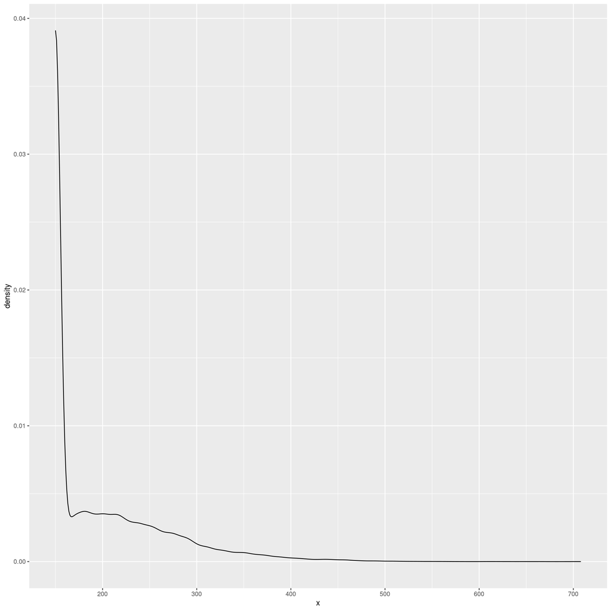

```r
islands.gr<-resize(acc_final_motifs.gr, 150, 'center') %>%
  GenomicRanges::reduce(ignore.strand = T)
# rtracklayer::export(islands.gr, 'bed/mapped_motifs/islands_raw.bed')

data.frame(x = width(islands.gr)) %>%
  ggplot(., aes(x = x))+
  geom_density()
```

```r
#Filter islands that are >1000 bp
islands.gr <- islands.gr %>% plyranges::filter(width <= input_length)  %>%
  plyranges::mutate(region_id = 0:(length(.)-1)) #Make region_id 0-based in order to be compatible with BPNet contribution .h5 file indexing properties.

#Nice! No regions get filtered out this time. This is great.

#Export regions in 0-based coordinates
rtracklayer::export(islands.gr %>%
                      plyranges::mutate(name = region_id),
                    'bed/mapped_motifs/all_accessibility_islands_curated_0based.bed', format = 'BED')
rtracklayer::export(islands.gr %>%
                      GenomicRanges::resize(., width = output_length, fix = 'center') %>%
                      plyranges::mutate(name = region_id),
                    'bed/mapped_motifs/all_accessibility_islands_curated_0based_sized_to_output.bed', format = 'BED')
rtracklayer::export(islands.gr %>%
                      GenomicRanges::resize(., width = input_length, fix = 'center') %>%
                      plyranges::mutate(name = region_id),
                    'bed/mapped_motifs/all_accessibility_islands_curated_0based_sized_to_input.bed', format = 'BED')
```

Show how many motifs there are per window

```r
ov<-findOverlaps(acc_final_motifs.gr, islands.gr, ignore.strand = T)
islands_resized_to_output.gr <- islands.gr %>% GenomicRanges::resize(., width = output_length, fix = 'center')

ov@to %>% table %>% table
```

```
## .
##     1     2     3     4     5     6     7     8     9    10    11    12    15
## 42564 20437 11076  5662  2702  1138   466   161    63    15     4     4     1
```

### Assign to accessibility motifs

```r
#Assign region_id to these motifs
acc_motifs_w_regions.gr<-acc_final_motifs.gr
acc_motifs_w_regions.gr$region_id<-NA
acc_motifs_w_regions.gr$region_id[ov@from]<-islands_resized_to_output.gr$region_id[ov@to]
acc_motifs_w_regions.gr$region_start_1based<-NA
acc_motifs_w_regions.gr$region_start_1based[ov@from]<-start(islands_resized_to_output.gr)[ov@to]
acc_motifs_w_regions.gr$region_end_1based<-NA
acc_motifs_w_regions.gr$region_end_1based[ov@from]<-end(islands_resized_to_output.gr)[ov@to]

#Filter motifs that aren't in a sufficiently small island.
acc_motifs_w_ic.gr <- acc_motifs_w_regions.gr %>% plyranges::filter(!is.na(region_id)) %>%
  plyranges::mutate(motif_id = 0:(length(.)-1), #0-based indexing later might come in handy
                    seq = getSeq(bsgenome, ., as.character = T))
```

### Export curated accessibility motifs

Show final results of motifs returned:

```r
acc_motifs_w_ic.gr$motif %>% table
```

```
## .
##      bHLH      Ctcf       Elk     Esrrb      Klf4       Nfy       Nrf      Oct4
##      1734      7363     13332     13236     66079      3709      1863       173
## Oct4-Sox2      Sox2  Tcfcp2l1     Tead4     Thap1    Zbtb33      Zic3
##     19690     19997      4511      6178       835       420      5906
```

Export curated motifs. In the subsequent .bed file it will be the `[task]_[motif_id]_[region_id]` naming convention.

```r
#1-based
acc_motifs_w_ic.df<-acc_motifs_w_ic.gr %>% as.data.frame()
readr::write_tsv(acc_motifs_w_ic.df, paste0('tsv/mapped_motifs/all_accessibility_instances_curated_1based.tsv.gz'))

#0-based
rtracklayer::export(acc_motifs_w_ic.gr %>% plyranges::mutate(name = paste0(motif, '_', motif_id, '_', region_id)),
                    paste0('bed/mapped_motifs/all_accessibility_instances_curated_0based.bed'))
```

# Align motifs

1. Align motifs such that subgroups have the same coordinates.
2. Align motifs such that the binding and accessibility versions have the same coordinates. For later assignment of affinity to seqlet-distribution %iles, we recorded the original starts and ends.

## Align the binding and accessibility motifs

In order to make fair comparisons, we want to make sure the motifs orient and are aligned positionally the same. Here, we will match the `motif` column for alignment. We will align the accessibility motifs to match the binding motifs.

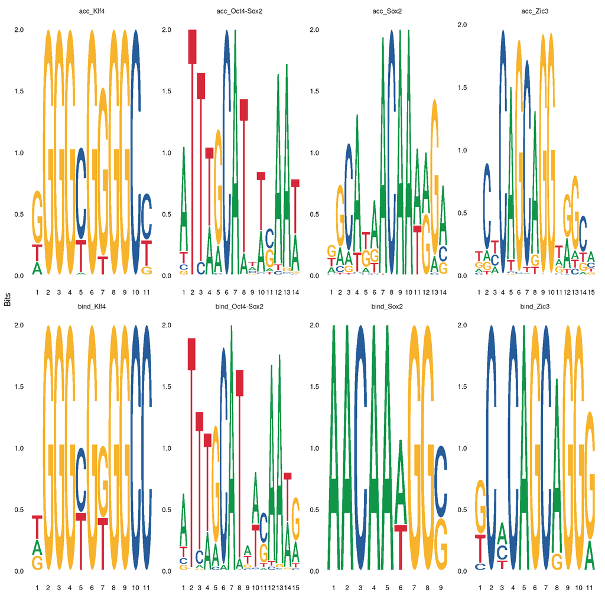

```r
shared_motifs.vec<-c('Klf4', 'Oct4-Sox2', 'Sox2', 'Zic3')

shared_acc_motifs.vec<-hits_dedup.list$atac_wt %>% plyranges::filter(motif %in% shared_motifs.vec) %>% .$motif %>% unique()
shared_bind_motifs.vec<-hits_dedup.list$bpnet_osknz %>% plyranges::filter(motif %in% shared_motifs.vec) %>% .$motif %>% unique()
acc_motifs_dedup.gr<-hits_dedup.list$atac_wt

#Plot the differences
acc_seqs.list<-lapply(shared_acc_motifs.vec, function(x){
  topmotif.gr<-acc_motifs_dedup.gr %>% plyranges::filter(motif==x) %>%
    plyranges::arrange(desc(seq_match_quantile)) %>% head(n=5000) %>%
  plyranges::mutate(seq = getSeq(bsgenome, ., as.character = TRUE))
  top500.seq<-topmotif.gr$seq
  return(top500.seq)
})
names(acc_seqs.list)<-paste0('acc_', shared_acc_motifs.vec)
bind_seqs.list<-lapply(shared_bind_motifs.vec, function(x){
  topmotif.gr<-hits_dedup.list$bpnet_osknz %>% plyranges::filter(motif==x) %>%
    plyranges::arrange(desc(seq_match_quantile)) %>% head(n=5000) %>%
  plyranges::mutate(seq = getSeq(bsgenome, ., as.character = TRUE))
  top500.seq<-topmotif.gr$seq
  return(top500.seq)
})
names(bind_seqs.list)<-paste0('bind_', shared_bind_motifs.vec)
all_seqs.list<-c(acc_seqs.list, bind_seqs.list)

ggseqlogo(all_seqs.list) +
  facet_wrap(~seq_group, ncol = 4, scales = 'free')
```

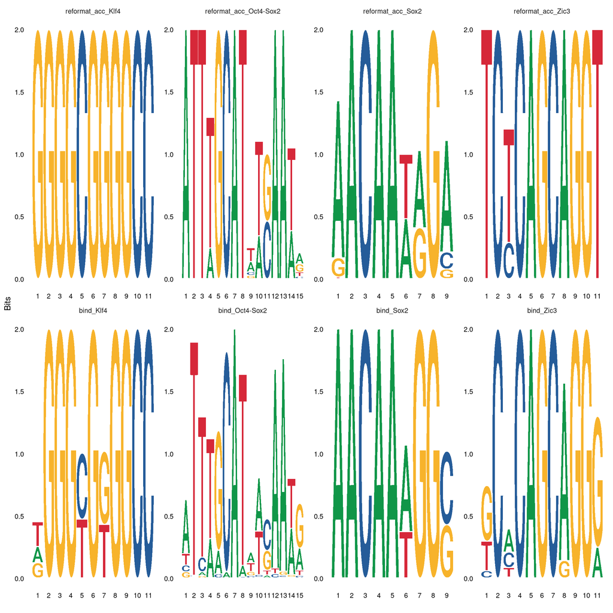

```r
# Set alignment criteria

#From the plot, generate a data.frame that shows the requirements for reformatting, this will include all logos except the first "anchor" unqiuemotif.
reformat.df<-data.frame(
  anchor_width = c(11, 15, 9, 11),
  motif = shared_acc_motifs.vec,
  flank_5p = c(0, 0, -5, 0), #amount of starting flank to add
  flank_3p = c(0, 1, 0, -4) #amount of ending flank to add
)

#Split the motifs out for processing
acc_motifs_nonunique.gr<-acc_motifs_dedup.gr %>% plyranges::filter(!(motif %in% shared_acc_motifs.vec))
acc_motifs_unique.gr<-acc_motifs_dedup.gr %>% plyranges::filter(motif %in% shared_acc_motifs.vec)

#Reformat the motifs
acc_unique_reformatted.gr<-lapply(shared_acc_motifs.vec, function(x){
  message(x)
  reformat_row.df<-reformat.df %>% dplyr::filter(motif==x)
  gr<-acc_motifs_unique.gr %>% plyranges::filter(motif==x)

  #Realign the motif after reformatted
  gr_pos.gr<-gr %>% plyranges::filter(strand == '+')
  gr_neg.gr<-gr %>% plyranges::filter(strand == '-')

  flank_5p<-reformat_row.df$flank_5p
  flank_3p<-reformat_row.df$flank_3p

  start(gr_pos.gr)<-start(gr_pos.gr) - flank_5p
  end(gr_pos.gr)<-end(gr_pos.gr) + flank_3p

  start(gr_neg.gr)<-start(gr_neg.gr) - flank_3p
  end(gr_neg.gr)<-end(gr_neg.gr) + flank_5p

  gr<-c(gr_pos.gr, gr_neg.gr)

  assert('Realignment is not working, some GRanges are not same width.', all(width(gr)==reformat_row.df$anchor_width))
  return(gr)
}) %>% as('GRangesList') %>% unlist(.)

#Check sequences to make sure they are aligned
reformatted_seqs.list<-lapply(shared_acc_motifs.vec, function(x){
  acc_unique_reformatted.gr %>%
    plyranges::filter(motif==x) %>%
    plyranges::mutate(seq = getSeq(bsgenome, ., as.character = TRUE)) %>%
    as.data.frame %>%
    dplyr::slice_max(seq_match_quantile, n = 500) %>% .$seq
})
names(reformatted_seqs.list)<-paste0('reformat_acc_', shared_acc_motifs.vec)
reformat_all_seqs.list<-c(reformatted_seqs.list, bind_seqs.list)

ggseqlogo(reformat_all_seqs.list)+
  facet_wrap(~seq_group, ncol = 4, scales = 'free')
```

```r
acc_motifs_aligned.gr<-c(acc_motifs_nonunique.gr, acc_unique_reformatted.gr)
hits_aligned.list<-hits_dedup.list
hits_aligned.list$atac_wt<-acc_motifs_aligned.gr
```

## Merge accessibility and binding motifs into single motif set

Here, now that all appropriate deduplication and alignment steps have been performed, we want to now merge the motifs that are mapped both by accessibility and binding models. This way, we will have a consolidated and annotated set of which motifs are unique to each feature and can assess these overlaps accordingly.

We will merge this via the `motif` and genomic coordinates, leaving the OS assessment of `motif` for later down the line.

```r
tf_motifs.gr<-hits_aligned.list$bpnet_osknz %>%
  plyranges::mutate(mapping_state = 'bind')
acc_motifs.gr<-hits_aligned.list$atac_wt %>%
  plyranges::mutate(mapping_state = 'acc')

all_motifs.gr<-lapply(shared_motifs.vec, function(x){
  #Subset motifs
  tf_motif.gr<-tf_motifs.gr %>%
    plyranges::filter(motif == x)
  acc_motif.gr<-acc_motifs.gr %>%
    plyranges::filter(motif == x)

  #Find overlaps
  min_width<-floor(unique(width(acc_motif.gr))/2) #needs to overlap by at least 1/2 of motif
  tf_vs_acc.ov<-findOverlaps(tf_motif.gr, acc_motif.gr, ignore.strand = T, minoverlap = min_width)

  #Isolate motif mapping states
  tf_motif.gr$mapping_state[unique(tf_vs_acc.ov@from)]<-'both'
  acc_motif.gr$mapping_state[unique(tf_vs_acc.ov@to)]<-'both'

  #Consoldiate motif set
  acc_only_motif.gr<-acc_motif.gr %>% plyranges::filter(mapping_state != 'both')
  all_motif.gr<-c(tf_motif.gr, acc_only_motif.gr)
}) %>% as('GRangesList') %>% unlist(.) %>%
  c(., tf_motifs.gr %>% plyranges::filter(!(motif %in% shared_motifs.vec)))


#Remove Sox2 motifs overlapping with Oct4-Sox2 motif.
sox2_motifs.gr<-all_motifs.gr %>% plyranges::filter(motif=='Sox2')
os_motifs.gr<-all_motifs.gr %>% plyranges::filter(motif=='Oct4-Sox2')
sox2_dedup_motifs.gr<-sox2_motifs.gr %>% plyranges::filter(!overlapsAny(sox2_motifs.gr, os_motifs.gr, ignore.strand = T))
print(paste0('Sox2 motifs removed from OS redundancy: ', length(sox2_motifs.gr) - length(sox2_dedup_motifs.gr)))
```

```
## [1] "Sox2 motifs removed from OS redundancy: 8682"
```

```r
dedup_w_s.gr<-c(all_motifs.gr %>% plyranges::filter(motif != 'Sox2'), sox2_dedup_motifs.gr)

#Remove Oct4 motifs overlapping with Oct4-Sox2 motif.
Oct4_motifs.gr<-dedup_w_s.gr %>% plyranges::filter(motif=='Oct4')
os_motifs.gr<-dedup_w_s.gr %>% plyranges::filter(motif=='Oct4-Sox2')
Oct4_dedup_motifs.gr<-Oct4_motifs.gr %>% plyranges::filter(!overlapsAny(Oct4_motifs.gr, os_motifs.gr, ignore.strand = T))
print(paste0('Oct4 motifs removed from OS redundancy: ', length(Oct4_motifs.gr) - length(Oct4_dedup_motifs.gr)))
```

```
## [1] "Oct4 motifs removed from OS redundancy: 1904"
```

```r
dedup_w_o.gr<-c(dedup_w_s.gr %>% plyranges::filter(motif != 'Oct4'), Oct4_dedup_motifs.gr)

#Remove Nanog motifs overlapping with Sox2/Oct4-Sox2 motif.
nanog_motifs.gr<-dedup_w_o.gr %>% plyranges::filter(motif=='Nanog')
other_motifs.gr<-dedup_w_o.gr %>% plyranges::filter(grepl('Sox2', motif))
nanog_dedup_motifs.gr<-nanog_motifs.gr %>% plyranges::filter(!overlapsAny(nanog_motifs.gr, other_motifs.gr, ignore.strand = T))
print(paste0('Nanog motifs removed from OS/S redundancy: ', length(nanog_motifs.gr) - length(nanog_dedup_motifs.gr)))
```

```
## [1] "Nanog motifs removed from OS/S redundancy: 3301"
```

```r
dedup_w_n.gr<-c(dedup_w_o.gr %>% plyranges::filter(motif != 'Nanog'), nanog_dedup_motifs.gr)

print(dedup_w_n.gr %>% as.data.frame %>% dplyr::group_by(motif) %>% dplyr::summarize(counts = dplyr::n()))
```

```
## # A tibble: 6 × 2
##   motif     counts
##   <chr>      <int>
## 1 Klf4      118382
## 2 Nanog      65959
## 3 Oct4         132
## 4 Oct4-Sox2  40682
## 5 Sox2       59781
## 6 Zic3       92751
```

```r
table(dedup_w_n.gr$motif, dedup_w_n.gr$mapping_state)
```

```
##
##               acc  bind  both
##   Klf4      20059 52303 46020
##   Nanog         0 65959     0
##   Oct4          0   132     0
##   Oct4-Sox2  3468 20992 16222
##   Sox2       4100 42540 13141
##   Zic3        579 86845  5327
```

Format the motifs.

```r
motifs.gr<-dedup_w_n.gr %>%
  plyranges::mutate(motif_id = 0:(length(.)-1), #0-based indexing later might come in handy
                    seq = getSeq(bsgenome, ., as.character = T))
```

## Align the quantile distributions across model motif calls

Because the ChromBPNet and BPNet models have different distributions of motif calls, we need to align the motif scores to match. We will align all motifs to the binding distributions and recalculate the `seq_match_quantile` scores.

```r
motifs_pre_quantiles.df<-motifs.gr %>% as.data.frame()
motifs.df<-lapply(motifs_pre_quantiles.df$motif %>% unique, function(x){
  message(x)
  #Obtain seqlets
  bind_seqlets.df<-seqlets_all.df %>% dplyr::filter(fold == 'fold1', model == 'bpnet_osknz', motif==x)
  if((seqlet_ids.df %>% dplyr::filter(fold == 'fold1', model == 'bpnet_osknz', motif==x) %>% .$oriented_strand)=='-'){
    bind_seqlets.df$sequence<-bind_seqlets.df$sequence %>% DNAStringSet() %>% reverseComplement() %>% as.character()
  }

  motif.df<-motifs_pre_quantiles.df %>% dplyr::filter(motif==x)
  seq_length<-nchar(motif.df$seq)[1]

  #Assert that you can map back sequences
  test<-((motif.df %>% dplyr::filter(motif==x, mapping_state != 'acc_only') %>%
            dplyr::group_by(seq_match, seq) %>%
            dplyr::summarize(seq_n = length(unique(seq))) %>%
            .$seq_n %>% table() %>% length()) == 1)
  testit::assert('seq_match is not 1:1 with seq', test[1])

  #Map trimmed binding sequences back to seqlets
  bind_seqlets.df<-bind_seqlets.df %>%
    dplyr::left_join(., motif.df %>% dplyr::select(seq, seq_match) %>% dplyr::mutate(dup = duplicated(seq)) %>% dplyr::filter(!dup) %>% dplyr::select(-dup), by = 'seq_match') %>%
    dplyr::mutate(seq = ifelse(is.na(seq), 'N', seq))

  if(all(bind_seqlets.df$seq == 'N')){
    start_index<-motif.df$seq %>% table %>% sort(decreasing = T) %>% .[1] %>% names(.) %>% gregexpr(pattern=., bind_seqlets.df$sequence) %>% unlist() %>%
      .[.>0] %>% table() %>% sort(decreasing = T) %>% .[1] %>% names(.) %>% as.integer()
  }else{
    #Impute motif boundaries from the most commonly occuring sequence match features
    start_index<-lapply(1:nrow(bind_seqlets.df), function(y){
      unlist(gregexpr(pattern=bind_seqlets.df$seq[y], bind_seqlets.df$sequence[y]))
    }) %>% unlist() %>% .[.>0] %>% table() %>% sort(decreasing = T) %>% .[1] %>% names(.) %>% as.integer()
  }
  #Reobtain seqlets
  bind_seqlets.df<-seqlets_all.df %>% dplyr::filter(fold == 'fold1', model == 'bpnet_osknz', motif==x)
  if((seqlet_ids.df %>% dplyr::filter(fold == 'fold1', model == 'bpnet_osknz', motif==x) %>% .$oriented_strand)=='-'){
    bind_seqlets.df$sequence<-bind_seqlets.df$sequence %>% DNAStringSet() %>% reverseComplement() %>% as.character()
  }
  bind_seqlets.df$seq_trimmed<-substr(bind_seqlets.df$sequence, start = start_index, stop = (start_index + seq_length - 1))

  #Get PPM and score and derive quantiles
  ppm<-seq_to_ppm(bind_seqlets.df$seq_trimmed)
  ic<-ppm_to_ic(ppm, bg_freq = c(.25, .25, .25, .25))
  bind_seqlets.df$seq_match<-mclapply(bind_seqlets.df$seq_trimmed, function(y) get_sequence_ic(y, ic), mc.cores = 12) %>% unlist()
  bind_seqlets.df$seq_match_quantile<-ecdf(bind_seqlets.df$seq_match)(bind_seqlets.df$seq_match)

  motif.df$seq_match<-mclapply(motif.df$seq, function(y) get_sequence_ic(y, ic), mc.cores = 12) %>% unlist()
  motif.df$seq_match_quantile<-ecdf(bind_seqlets.df$seq_match)(motif.df$seq_match)

  motif.df<-motif.df %>%
    dplyr::select(-contrib_magnitude, -contrib_magnitude_quantile, -contrib_match, -contrib_match_quantile)

  return(motif.df)
}) %>% rbindlist()
motifs.gr<-motifs.df %>% makeGRangesFromDataFrame(keep.extra.columns = T, starts.in.df.are.0based = F)
```

# Annotate motifs by their collected regional grouping

Because we took motifs based on their relative contribution and not the featured `peak_index` column, we need a new grouping annotation to define the motifs when we are conducting perturbations and other grouping systems. We will call this index `region_id`.

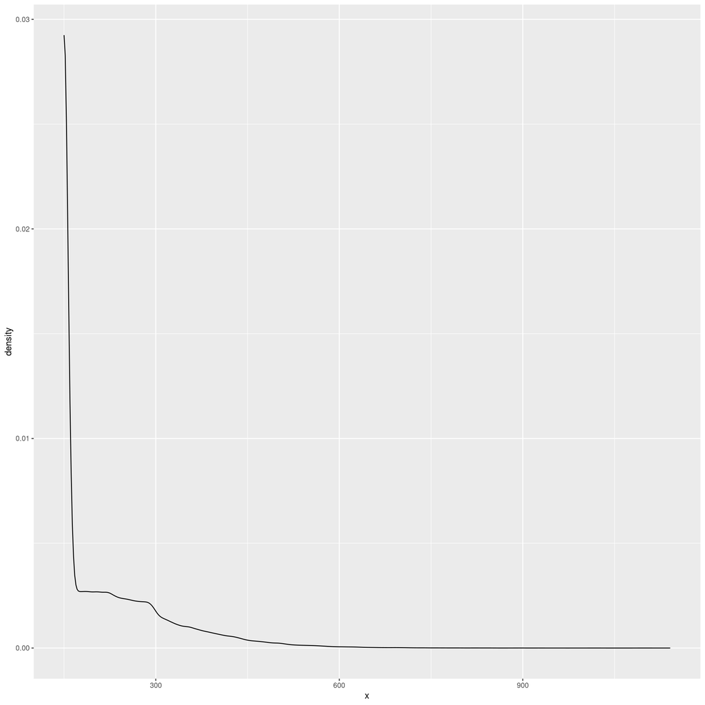

```r
islands.gr<-resize(motifs.gr, 150, 'center') %>%
  GenomicRanges::reduce(ignore.strand = T)
# rtracklayer::export(islands.gr, 'bed/mapped_motifs/islands_raw.bed')

data.frame(x = width(islands.gr)) %>%
  ggplot(., aes(x = x))+
  geom_density()
```

```r
#Filter islands that are >1000 bp
islands.gr <- islands.gr %>% plyranges::filter(width <= input_length)  %>%
  plyranges::mutate(region_id = 0:(length(.)-1)) #Make region_id 0-based in order to be compatible with BPNet contribution .h5 file indexing properties.

#Nice! No regions get filtered out this time. This is great.

#Export regions in 0-based coordinates
rtracklayer::export(islands.gr %>%
                      plyranges::mutate(name = region_id),
                    'bed/mapped_motifs/all_islands_curated_0based.bed', format = 'BED')
rtracklayer::export(islands.gr %>%
                      GenomicRanges::resize(., width = output_length, fix = 'center') %>%
                      plyranges::mutate(name = region_id),
                    'bed/mapped_motifs/all_islands_curated_0based_sized_to_output.bed', format = 'BED')
rtracklayer::export(islands.gr %>%
                      GenomicRanges::resize(., width = input_length, fix = 'center') %>%
                      plyranges::mutate(name = region_id),
                    'bed/mapped_motifs/all_islands_curated_0based_sized_to_input.bed', format = 'BED')
```

Show how many motifs there are per window

```r
ov<-findOverlaps(motifs.gr, islands.gr, ignore.strand = T)
islands_resized_to_output.gr <- islands.gr %>% GenomicRanges::resize(., width = output_length, fix = 'center')

ov@to %>% table %>% table
```

```
## .
##     1     2     3     4     5     6     7     8     9    10    11    12    13
## 80995 33923 20888 13138  8353  4835  2647  1387   680   329   152    64    40
##    14    15    16    17    18    20    21    22    24    25    27    28    35
##    19     6     2     3     4     1     2     3     1     1     1     1     1
##    36    46
##     1     1
```

Calculate experimental coverage, CpG density, and promoter presence across islands, and save metadata.

First, collect ChIP-nexus data.

```r
#Collect coverage across regions
tf_counts.df<-mclapply(names(nexus.bw.list), function(x){
  regionSums(islands_resized_to_output.gr, nexus.bw.list[[x]]$pos)  +
    abs(regionSums(islands_resized_to_output.gr, nexus.bw.list[[x]]$neg))
}, mc.cores = 5) %>% as.data.frame()
colnames(tf_counts.df)<-names(nexus.bw.list)
```

Next, collect predicted ChIP-nexus data

```r
tf_pred_counts.df<-mclapply(names(nexus.bw.list), function(x){

  pred.bw.list<-list(pos = paste0('preds/bpnet_osknz_fold1_', x, '_pos_peaks_all.bw'),
                     neg = paste0('preds/bpnet_osknz_fold1_', x, '_neg_peaks_all.bw'))

  regionSums(islands_resized_to_output.gr, pred.bw.list$pos)  +
    abs(regionSums(islands_resized_to_output.gr, pred.bw.list$neg))

}, mc.cores = 5) %>% as.data.frame()
colnames(tf_pred_counts.df)<-paste0(names(nexus.bw.list), '_pred')
```

Next, collect and consolidate experimental data, presence of promoters, and CpG density. CpG density was manually calculated based on the 2006 publication that originated this particular density function (https://www.pnas.org/doi/full/10.1073/pnas.0510310103).

```r
tss.gr<-txdb %>% transcripts(.) %>% resize(., width = 1, fix = 'start')
islands_resized_to_output.gr<-islands_resized_to_output.gr %>%
  as.data.frame %>%
  cbind(., tf_counts.df) %>%
  cbind(., tf_pred_counts.df) %>%
  makeGRangesFromDataFrame(keep.extra.columns = T, starts.in.df.are.0based = F) %>%
  plyranges::mutate(
    contains_tss = overlapsAny(., tss.gr),
    island_seq = getSeq(bsgenome, GRanges(seqnames, IRanges(start, end)), as.character = T),
    C = stringr::str_count(island_seq, 'C'),
    G = stringr::str_count(island_seq, 'G'),
    CpG = stringr::str_count(island_seq, 'CG'),
    CpG_ratio = round((CpG) / ((((C + G) / 2) ^ 2) / width), 2),
    atac_obs = regionSums(., atac_obs.bw),
    atac_pred = regionSums(., atac_pred.bw))
```

Mark nearest gene.

```r
tss.gr<-genes(TxDb.Mmusculus.UCSC.mm10.knownGene, columns=c("gene_id"))
id_to_symbol.df <- AnnotationDbi::select(org.Mm.eg.db, keys = tss.gr$gene_id,
                                          columns = c("SYMBOL","ENTREZID"),
                                          keytype = "ENTREZID")

islands_resized_to_output.gr$nearest_gene_id<-tss.gr[nearest(islands_resized_to_output.gr, tss.gr)]$gene_id
islands_resized_to_output.gr$nearest_gene_start<-start(tss.gr[nearest(islands_resized_to_output.gr, tss.gr)])
islands_resized_to_output.gr$nearest_gene_distance<-abs(start(resize(islands_resized_to_output.gr, 1, 'center')) - islands_resized_to_output.gr$nearest_gene_start)
islands_resized_to_output.gr$nearest_gene_name<-islands_resized_to_output.gr %>% as.data.frame %>%
  dplyr::select(nearest_gene_id) %>%
  dplyr::left_join(., id_to_symbol.df %>% dplyr::rename(nearest_gene_id = ENTREZID, nearest_gene_name = SYMBOL)) %>%
  .$nearest_gene_name
```

## Assign to motifs

```r
#Assign region_id to these motifs
motifs_w_regions.gr<-motifs.gr
motifs_w_regions.gr$region_id<-NA
motifs_w_regions.gr$region_id[ov@from]<-islands_resized_to_output.gr$region_id[ov@to]
motifs_w_regions.gr$region_start_1based<-NA
motifs_w_regions.gr$region_start_1based[ov@from]<-start(islands_resized_to_output.gr)[ov@to]
motifs_w_regions.gr$region_end_1based<-NA
motifs_w_regions.gr$region_end_1based[ov@from]<-end(islands_resized_to_output.gr)[ov@to]

#Filter motifs that aren't in a sufficiently small island.
motifs_w_ic.gr <- motifs_w_regions.gr %>% plyranges::filter(!is.na(region_id))
```

# Calculate islands

Perform island analysis

```r
island_classes.df<-motifs_w_ic.gr %>%
  GenomicRanges::sort(ignore.strand = T) %>%
  as.data.frame %>%
  dplyr::group_by(region_id) %>%
  dplyr::summarize(island_content = paste(unique(sort(motif)), table(sort(motif)), sep = ':', collapse = '_'),
                   island_content_ordered = paste(motif, collapse = '_'),
                   island_content_unique = paste(unique(sort(motif)), collapse = '_'),
                   island_count = length(motif))

islands_resized_to_output.gr<-islands_resized_to_output.gr %>% as.data.frame %>% dplyr::left_join(., island_classes.df) %>%
  makeGRangesFromDataFrame(keep.extra.columns = T, starts.in.df.are.0based = F)
motifs_w_ic.gr<-motifs_w_ic.gr %>% as.data.frame %>% dplyr::left_join(., island_classes.df) %>%
  makeGRangesFromDataFrame(keep.extra.columns = T, starts.in.df.are.0based = F)
```

Last, save this as an .RDS file and as .tsv metadata.

```r
saveRDS(islands_resized_to_output.gr, 'rdata/mapped_motifs/all_islands_curated_1based_w_experimental_data.gr.rds')
readr::write_tsv(islands_resized_to_output.gr %>% as.data.frame, 'tsv/mapped_motifs/all_islands_curated_1based_w_experimental_data.tsv.gz')
```

```r
islands_resized_to_output.gr$CpG %>% summary()
```

```
##    Min. 1st Qu.  Median    Mean 3rd Qu.    Max.
##    0.00    8.00   13.00   19.97   21.00  173.00
```

```r
islands_resized_to_output.gr$C %>% summary()
```

```
##    Min. 1st Qu.  Median    Mean 3rd Qu.    Max.
##      33     210     235     240     264     518
```

```r
islands_resized_to_output.gr$G %>% summary()
```

```
##    Min. 1st Qu.  Median    Mean 3rd Qu.    Max.
##    63.0   210.0   235.0   239.9   264.0   499.0
```

```r
islands_resized_to_output.gr$CpG_ratio %>% summary()
```

```
##    Min. 1st Qu.  Median    Mean 3rd Qu.    Max.
##  0.0000  0.1600  0.2300  0.2964  0.3600  1.6200
```

## Collect contribution scores

```r
#Collect accessibility contribution
motifs_w_acc.gr<-motifs_w_ic.gr %>%
  plyranges::mutate(acc_contrib = regionSums(., acc_counts_contrib.bw))

#Collect tf binding contribution
tf_contrib.df<-mclapply(tasks, function(x){
  regionSums(motifs_w_acc.gr, paste0('shap/bpnet_osknz_fold1_', x, '_counts.bw'))
}, mc.cores = length(tasks)) %>% as.data.frame(.)
colnames(tf_contrib.df)<-paste0(tasks, '_contrib')

#Format contribution
motifs_w_metadata.gr<-motifs_w_acc.gr %>%
  as.data.frame %>%
  cbind(., tf_contrib.df) %>%
  makeGRangesFromDataFrame(keep.extra.columns = T, starts.in.df.are.0based = F)

#Create TF-motif specific column
motifs_w_metadata.gr<-lapply(names(motif_to_task.list), function(x){
  motif.df<-motifs_w_metadata.gr %>% plyranges::filter(motif == x) %>% as.data.frame(.)
  motif.df$bind_contrib<-motif.df[[paste0(motif_to_task.list[[x]], '_contrib')]]
  return(makeGRangesFromDataFrame(motif.df, keep.extra.columns = T, starts.in.df.are.0based = F))
}) %>% as('GRangesList') %>% unlist(.)
```

## Mark ERVs

```r
repeats.gr<-readRDS(repeats.path)
ervs.gr<-repeats.gr %>% plyranges::filter(grepl('ERV', repeat_class))
motifs_w_metadata.gr$is_across_erv <- overlapsAny(motifs_w_metadata.gr, ervs.gr, ignore.strand = T)
```

# Export curated motifs

Show final results of motifs returned:

```r
motifs_w_metadata.gr$motif %>% table
```

```
## .
##      Klf4     Nanog      Oct4 Oct4-Sox2      Sox2      Zic3
##    118382     65959       132     40682     59781     92751
```

Export curated motifs. In the subsequent .bed file it will be the `[task]_[motif_id]_[region_id]` naming convention.

```r
#1-based
motifs.df<-motifs_w_metadata.gr %>% as.data.frame()
readr::write_tsv(motifs.df, paste0('tsv/mapped_motifs/all_instances_curated_1based.tsv.gz'))

#0-based
rtracklayer::export(motifs_w_metadata.gr %>% plyranges::mutate(name = paste0(motif, '_', motif_id, '_', region_id)),
                    paste0('bed/mapped_motifs/all_instances_curated_0based.bed'))
```

# Curate Xiong et al motif mappings

From the ATAC-seq time course experiments, select the “WT” timepoint (0h) and map motifs such that we can do analysis on them later.

```r
xiong_motif_key.df<-data.frame(pattern_name = c('pattern_0','pattern_1','pattern_2'), motif = c('Klf4','Sox2','Oct4-Sox2'), oriented_strand = c('+', '+', '-'))

#Read in data
xiong_motifs.gr<-readr::read_tsv('modiscolite/atac_0h_fold1_atac_counts/hits.tsv') %>%
  dplyr::filter(metacluster_name == 'pos_patterns', pattern_name %in% c('pattern_0','pattern_1','pattern_2')) %>%
  dplyr::left_join(xiong_motif_key.df) %>%
  dplyr::mutate(strand = ifelse(oriented_strand == '-',
                                ifelse(strand == '-', '+', '-'),
                                strand)) %>%
  makeGRangesFromDataFrame(keep.extra.columns = T, starts.in.df.are.0based = T)
```

Curate redundnacy by mapping to a distinct set of islands. Export islands.

```r
xiong_regions.gr<-xiong_motifs.gr %>% GenomicRanges::resize(., 150, 'center') %>% GenomicRanges::reduce(ignore.strand = T) %>%
  plyranges::mutate(region_id = 0:(length(.)-1)) #Make region_id 0-based in order to be compatible with BPNet contribution .h5 file indexing properties.
xiong_motif_vs_regions.ov<-findOverlaps(xiong_motifs.gr, xiong_regions.gr, ignore.strand = T)
xiong_motifs.gr$region_id<-xiong_regions.gr$region_id[xiong_motif_vs_regions.ov@to]
```

Ensure Oct4-Sox2 motifs are not overlapping Sox2 motifs. Check this explicitly.

```r
os_xiong.gr<-xiong_motifs.gr %>% plyranges::filter(motif == 'Oct4-Sox2')
s_xiong.gr<-xiong_motifs.gr %>% plyranges::filter(motif == 'Sox2')

#Remove Sox2 motifs overlapping with Oct4-Sox2 motif.
s_dedup_xiong.gr<-s_xiong.gr %>% plyranges::filter(!overlapsAny(s_xiong.gr, os_xiong.gr, ignore.strand = T))
print(paste0('Sox2 motifs removed from OS redundancy: ', length(s_xiong.gr) - length(s_dedup_xiong.gr)))
```

```
## [1] "Sox2 motifs removed from OS redundancy: 9397"
```

```r
xiong_os_dedup_motifs.gr<-c(xiong_motifs.gr %>% plyranges::filter(motif != 'Sox2'), s_dedup_xiong.gr)
```

Curate redundancy by making sure NO motif overlaps. We will select overlapping motif from grouped set based on `contrib_magnitude`.

```r
xiong_motifs_dedup.gr<-lapply(c('Oct4-Sox2', 'Sox2','Klf4'), function(x){
  remove_palindromic_motifs_from_bpnet_instances(xiong_os_dedup_motifs.gr,
                                                 pattern_to_filter = x,
                                                 chrom_name = 'seqnames',
                                                 start_name = 'start',
                                                 end_name = 'end',
                                                 value_name = 'contrib_magnitude', #Pick longer xiong_motif typically
                                                 motif_name = 'motif',
                                                 region_name = 'region_id')
}) %>% as('GRangesList') %>% unlist %>%
  plyranges::mutate(motif_id = 0:(length(.)-1),
                    seq = getSeq(bsgenome, .))
```

Export all motifs and regions.

```r
#Export regions in 0-based coordinates
rtracklayer::export(xiong_regions.gr %>%
                      plyranges::mutate(name = region_id),
                    'bed/mapped_motifs/all_xiong_islands_curated_0based.bed', format = 'BED')
rtracklayer::export(xiong_regions.gr %>%
                      GenomicRanges::resize(., width = output_length, fix = 'center') %>%
                      plyranges::mutate(name = region_id),
                    'bed/mapped_motifs/all_xiong_islands_curated_0based_sized_to_output.bed', format = 'BED')
rtracklayer::export(xiong_regions.gr %>%
                      GenomicRanges::resize(., width = input_length, fix = 'center') %>%
                      plyranges::mutate(name = region_id),
                    'bed/mapped_motifs/all_xiong_islands_curated_0based_sized_to_input.bed', format = 'BED')

#1-based
xiong_motifs_dedup.df<-xiong_motifs_dedup.gr %>% as.data.frame()
readr::write_tsv(xiong_motifs_dedup.df, paste0('tsv/mapped_motifs/all_xiong_instances_curated_1based.tsv.gz'))

#0-based
rtracklayer::export(xiong_motifs_dedup.gr %>% plyranges::mutate(name = paste0(motif, '_', motif_id, '_', region_id)),
                    paste0('bed/mapped_motifs/all_xiong_instances_curated_0based.bed'))
```

# Compare BPNet and ChromBPNet mappings

## Sequence match scores

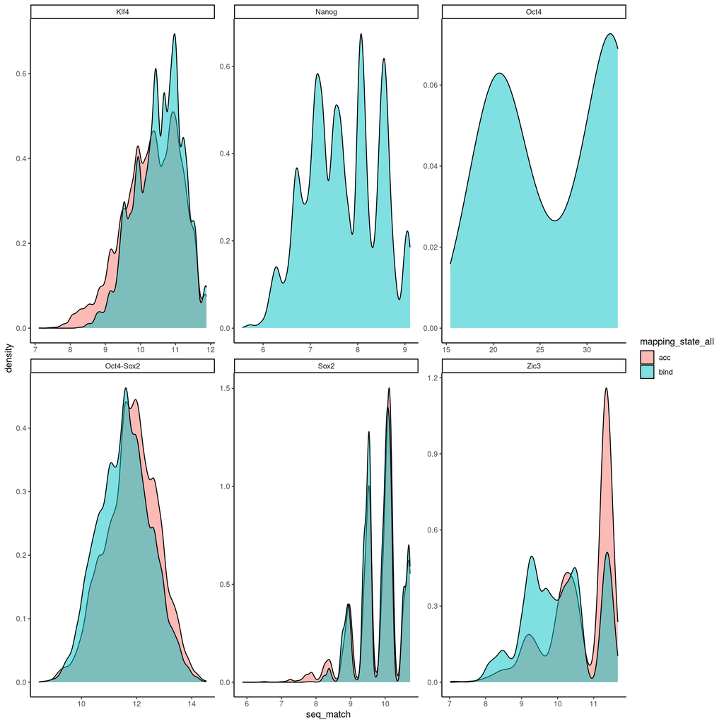

```r
bpnet_vs_chrombpnet.plot<-rbind(
  motifs.df %>%
    dplyr::filter(mapping_state %in% c('bind', 'both')) %>%
    dplyr::mutate(mapping_state_all = 'bind') %>%
    dplyr::group_by(motif),
motifs.df %>%
  dplyr::filter(mapping_state %in% c('acc', 'both')) %>%
  dplyr::mutate(mapping_state_all = 'acc') %>%
  dplyr::group_by(motif)
) %>%
  ggplot(., aes(x = seq_match, fill = mapping_state_all))+
  geom_density(alpha = .5)+
  facet_wrap(~ motif, scales = 'free')+
  theme_classic()
bpnet_vs_chrombpnet.plot
```

```r
ggsave(paste0(figure_filepath, '/bpnet_vs_chrombpnet_seq_match.png'), bpnet_vs_chrombpnet.plot, height = 4, width = 8)
ggsave(paste0(figure_filepath, '/bpnet_vs_chrombpnet_seq_match.pdf'), bpnet_vs_chrombpnet.plot, height = 4, width = 8)

##Statistically validate
ks.test(x = motifs.df %>%
          dplyr::filter(mapping_state %in% c('bind', 'both')) %>% .$seq_match,
        y = motifs.df %>%
          dplyr::filter(mapping_state %in% c('acc', 'both')) %>% .$seq_match)
```

```
##
##  Asymptotic two-sample Kolmogorov-Smirnov test
##
## data:  motifs.df %>% dplyr::filter(mapping_state %in% c("bind", "both")) %>% .$seq_match and motifs.df %>% dplyr::filter(mapping_state %in% c("acc", "both")) %>% .$seq_match
## D = 0.19578, p-value < 2.2e-16
## alternative hypothesis: two-sided
```

## Frequency

```r
motifs.df %>%
  dplyr::group_by(motif, mapping_state) %>%
  dplyr::summarize(count = dplyr::n())
```

```
## # A tibble: 14 × 3
## # Groups:   motif [6]
##    motif     mapping_state count
##    <chr>     <chr>         <int>
##  1 Klf4      acc           20059
##  2 Klf4      bind          52303
##  3 Klf4      both          46020
##  4 Nanog     bind          65959
##  5 Oct4      bind            132
##  6 Oct4-Sox2 acc            3468
##  7 Oct4-Sox2 bind          20992
##  8 Oct4-Sox2 both          16222
##  9 Sox2      acc            4100
## 10 Sox2      bind          42540
## 11 Sox2      both          13141
## 12 Zic3      acc             579
## 13 Zic3      bind          86845
## 14 Zic3      both           5327
```

# Compare motif count to Avsec (2021)

We mapped motifs without requiring a sequence match score criteria. How different are our results?

## Import Avsec motifs

```r
avsec_motifs.path<-'/n/projects/mw2098/publications/2019_avsec_bpnet/data/tsv/dfi_subset.tsv'
avsec_peaks.path<-'/n/projects/mw2098/publications/2019_avsec_bpnet/data/bed/peaks.bed'

# motifs_w_metadata.gr<-motifs.df %>% makeGRangesFromDataFrame(keep.extra.columns = T, seqnames.field = 'seqnames', start.field = 'start', end.field = 'end', strand.field = 'strand')
# islands_resized_to_output.gr<-readRDS('rdata/mapped_motifs/all_islands_curated_1based_w_experimental_data.gr.rds')

#Find where avsec peaks and our peaks overlap
avsec_peaks.gr<-rtracklayer::import(avsec_peaks.path) %>%
  subsetByOverlaps(islands_resized_to_output.gr, .)

avsec_motifs.gr<-readr::read_tsv(avsec_motifs.path) %>%
  makeGRangesFromDataFrame(keep.extra.columns = T, starts.in.df.are.0based = T, seqnames.field = 'example_chrom',
                           start.field = 'pattern_start_abs', end.field = 'pattern_end_abs') %>%
  plyranges::filter(pattern_name %in% names(motif_to_task.list)) %>%
  plyranges::filter(pattern_name != 'Zic3')
```

## Curate Avsec motifs

Curate Avsec motifs using the same rigor as our mapped hits. We need to consider motifs that are shared between the appropriate peak mapped sets as our baseline, as they are trained on slightly different regions.

```r
#Import peaks and reduce them to a deduplicated state to get general peak regions.
p.gr<-avsec_peaks.gr %>%
  GenomicRanges::resize(., input_length, fix = 'center') %>%
  GenomicRanges::reduce(., ignore.strand = T) %>%
  plyranges::mutate(region_id_tmp = 1:length(.))

#Find overlaps between motifs and peaks
ov<-findOverlaps(avsec_motifs.gr, p.gr, ignore.strand = T)

#Assign temporary region ID for deduplication
avsec_motifs.gr$region_id_tmp<-NA
avsec_motifs.gr$region_id_tmp[ov@from]<-p.gr$region_id_tmp[ov@to]

#Filter any motif that doesn't fit into peaks. This means that the motif is mapped on the edges of the general, temporary region_id
avsec_motifs.gr<-avsec_motifs.gr %>% plyranges::filter(!is.na(avsec_motifs.gr$region_id_tmp))

#Deduplicate any motifs for palindromic mappings
avsec_motifs_aligned.gr<-lapply(unique(avsec_motifs.gr$pattern_name), function(y){
  print(y)
  motifs.gr<-avsec_motifs.gr %>% plyranges::filter(pattern_name==y)
  motifs_dedup.gr<-remove_palindromic_motifs_from_bpnet_instances(dfi = motifs.gr,
                                                                  pattern_to_filter = y,
                                                                  chrom_name = 'example_chrom',
                                                                  start_name = 'example_start', end_name = 'example_end',
                                                                  value_name = 'seq_match_p', motif_name = 'pattern_name',
                                                                  region_name = 'region_id_tmp')
  print(paste0(length(motifs_dedup.gr) , ' kept from ', length(motifs.gr)))
  return(motifs_dedup.gr)
}) %>% as('GRangesList') %>% unlist(.)
```

```
## [1] "Oct4-Sox2"
```

```
## [1] "22313 kept from 47119"
## [1] "Oct4"
```

```
## [1] "34396 kept from 64335"
## [1] "Sox2"
```

```
## [1] "19037 kept from 35941"
## [1] "Nanog"
```

```
## [1] "40874 kept from 65426"
## [1] "Klf4"
```

```
## [1] "52431 kept from 87229"
```

```r
#Remove Sox2 motifs overlapping with Oct4-Sox2 motif.
sox2_motifs.gr<-avsec_motifs_aligned.gr %>% plyranges::filter(pattern_name=='Sox2')
os_motifs.gr<-avsec_motifs_aligned.gr %>% plyranges::filter(pattern_name=='Oct4-Sox2')
sox2_dedup_motifs.gr<-sox2_motifs.gr %>% plyranges::filter(!overlapsAny(sox2_motifs.gr, os_motifs.gr, ignore.strand = T))
print(paste0('Sox2 motifs removed from OS redundancy: ', length(sox2_motifs.gr) - length(sox2_dedup_motifs.gr)))
```

```
## [1] "Sox2 motifs removed from OS redundancy: 783"
```

```r
dedup_w_s.gr<-c(avsec_motifs_aligned.gr %>% plyranges::filter(pattern_name != 'Sox2'), sox2_dedup_motifs.gr)

#Remove Oct4 motifs overlapping with Oct4-Sox2 motif.
Oct4_motifs.gr<-dedup_w_s.gr %>% plyranges::filter(pattern_name=='Oct4')
os_motifs.gr<-dedup_w_s.gr %>% plyranges::filter(pattern_name=='Oct4-Sox2')
Oct4_dedup_motifs.gr<-Oct4_motifs.gr %>% plyranges::filter(!overlapsAny(Oct4_motifs.gr, os_motifs.gr, ignore.strand = T))
print(paste0('Oct4 motifs removed from OS redundancy: ', length(Oct4_motifs.gr) - length(Oct4_dedup_motifs.gr)))
```

```
## [1] "Oct4 motifs removed from OS redundancy: 12154"
```

```r
dedup_w_o.gr<-c(dedup_w_s.gr %>% plyranges::filter(pattern_name != 'Oct4'), Oct4_dedup_motifs.gr)

#Remove Nanog motifs overlapping with Sox2/Oct4-Sox2 motif.
nanog_motifs.gr<-dedup_w_o.gr %>% plyranges::filter(pattern_name=='Nanog')
other_motifs.gr<-dedup_w_o.gr %>% plyranges::filter(grepl('Sox2', pattern_name))
nanog_dedup_motifs.gr<-nanog_motifs.gr %>% plyranges::filter(!overlapsAny(nanog_motifs.gr, other_motifs.gr, ignore.strand = T))
print(paste0('Nanog motifs removed from OS/S redundancy: ', length(nanog_motifs.gr) - length(nanog_dedup_motifs.gr)))
```

```
## [1] "Nanog motifs removed from OS/S redundancy: 1353"
```

```r
dedup_w_n.gr<-c(dedup_w_o.gr %>% plyranges::filter(pattern_name != 'Nanog'), nanog_dedup_motifs.gr)

print(dedup_w_n.gr %>% as.data.frame %>% dplyr::group_by(pattern_name) %>% dplyr::summarize(counts = dplyr::n()))
```

```
## # A tibble: 5 × 2
##   pattern_name counts
##   <chr>         <int>
## 1 Klf4          52431
## 2 Nanog         39521
## 3 Oct4          22242
## 4 Oct4-Sox2     22313
## 5 Sox2          18254
```

```r
avsec_motifs_aligned.gr<-dedup_w_n.gr %>%
  plyranges::arrange(pattern_name) %>%
  plyranges::mutate(motif_id = 0:(length(.)-1)) %>%
  plyranges::select(-c(region_id_tmp)) %>%
  subsetByOverlaps(., avsec_peaks.gr, ignore.strand = T)
avsec_motifs_aligned.gr$pattern_name %>% table
```

```
## .
##      Klf4     Nanog      Oct4 Oct4-Sox2      Sox2
##     50263     38031     21169     21646     17749
```

```r
rtracklayer::export(avsec_motifs_aligned.gr %>% plyranges::mutate(name = pattern_name), 'bed/avsec_motifs_recurated.bed')

# Filter new motifs by avsec peaks for fair comparison.
# This is done in a TF-specific manner as per the methods of the 2021 paper
# (original modisco settings)
new_motifs_aligned.gr<-motifs_w_metadata.gr %>% subsetByOverlaps(., avsec_peaks.gr, ignore.strand = T) %>%
  plyranges::filter(motif != 'Zic3')
new_motifs_aligned.gr$motif %>% table
```

```
## .
##      Klf4     Nanog      Oct4 Oct4-Sox2      Sox2
##     95637     54560        83     33392     47944
```

## Compare Avsec motifs to newly mapped motifs

First, compare relative numbers.

```r
consolidated.gr<-lapply(unique(avsec_motifs.gr$pattern_name), function(y){
  print(y)

  #Collect metadata from avsec motifs and format to fit current motifs
  a_motifs.gr<-avsec_motifs.gr %>% plyranges::filter(pattern_name==y) %>% plyranges::mutate(motif = pattern_name) %>%
    plyranges::select(motif) %>%
    plyranges::mutate(motif_state = 'avsec_motifs')
  a_vs_peaks.ov<-findOverlaps(a_motifs.gr, avsec_peaks.gr, ignore.strand = T)
  a_motifs.gr$region_id<-NA
  a_motifs.gr$region_id[a_vs_peaks.ov@from]<-avsec_peaks.gr$region_id[a_vs_peaks.ov@to]

  #Mark whether motifs are unique to the mapping sets
  n_motifs.gr<-new_motifs_aligned.gr %>% plyranges::filter(motif==y) %>%
    plyranges::select(motif, region_id) %>%
    plyranges::mutate(motif_state = 'current_motifs')

  a_vs_n.ov<-findOverlaps(n_motifs.gr, a_motifs.gr, ignore.strand = T)

  n_motifs.gr$motif_state[unique(a_vs_n.ov@from)]<-'both'
  a_motifs.gr$motif_state[unique(a_vs_n.ov@to)]<-'both'

  motifs.gr<-c(n_motifs.gr, a_motifs.gr %>% plyranges::filter(motif_state != 'both'))
  return(motifs.gr)
}) %>% as('GRangesList') %>% unlist(.) %>%
  plyranges::mutate(motif = factor(motif, levels = c('Oct4-Sox2','Sox2','Nanog', 'Klf4', 'Oct4')))
```

```
## [1] "Oct4-Sox2"
## [1] "Oct4"
## [1] "Sox2"
## [1] "Nanog"
## [1] "Klf4"
```

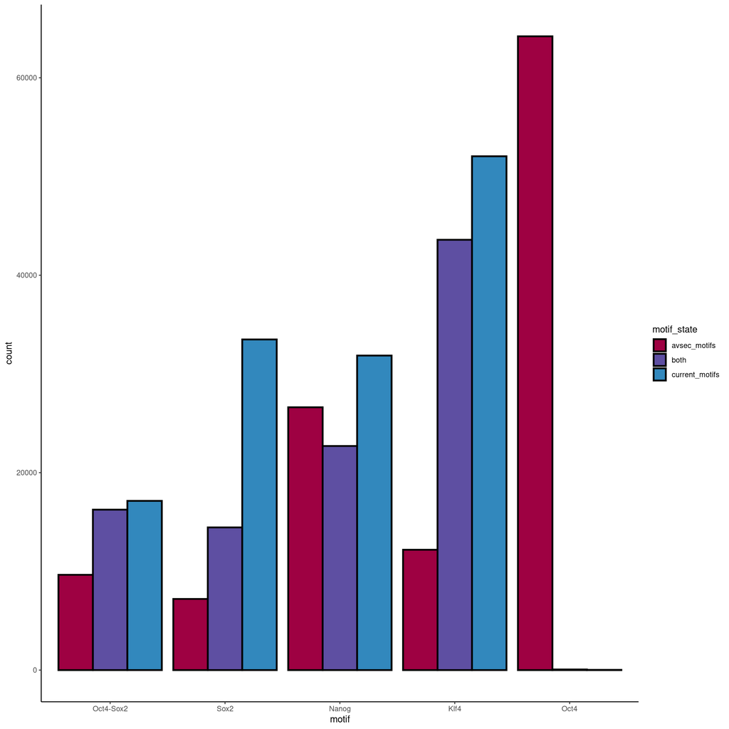

```r
motif_count.plot<-ggplot(consolidated.gr %>% as.data.frame, aes(x = motif, fill = motif_state))+
  geom_bar(position = 'dodge', color = 'black', linewidth = 1) +
  scale_fill_manual(values = c('#9e0142', '#5e4fa2', '#3288bd'))+
  theme_classic()
motif_count.plot
```

```r
ggsave(paste0(figure_filepath, '/motifs_vs_avsec_counts.png'), motif_count.plot, height = 4, width = 5)
ggsave(paste0(figure_filepath, '/motifs_vs_avsec_counts.pdf'), motif_count.plot, height = 4, width = 5)

consolidated.gr %>%
  as.data.frame %>%
  dplyr::group_by(motif_state) %>%
  dplyr::summarize(counts = dplyr::n())
```

```
## # A tibble: 3 × 2
##   motif_state    counts
##   <chr>           <int>
## 1 avsec_motifs   119865
## 2 both            97054
## 3 current_motifs 134562
```

Next, compare relative number of motifs per region.

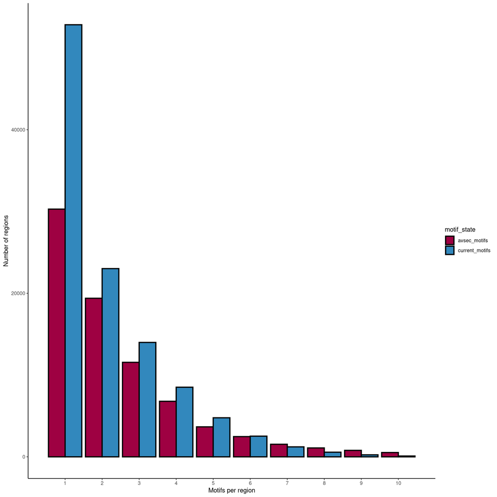

```r
c.df<-consolidated.gr %>%
  as.data.frame %>%
  dplyr::mutate(avsec_state = ifelse(motif_state != 'current_motifs', T, F),
                current_state = ifelse(motif_state != 'avsec_motifs', T, F))

#Get current distribution
dist.df<-rbind(
  c.df %>%
    dplyr::filter(avsec_state) %>%
    dplyr::group_by(region_id) %>%
    dplyr::summarize(motif_count = dplyr::n()) %>%
    dplyr::mutate(motif_state = 'avsec_motifs'),
  c.df %>%
    dplyr::filter(current_state) %>%
    dplyr::group_by(region_id) %>%
    dplyr::summarize(motif_count = dplyr::n()) %>%
    dplyr::mutate(motif_state = 'current_motifs')
)

region_group.plot<-ggplot(dist.df, aes(x = motif_count, fill = motif_state))+
  geom_bar(position = 'dodge', linewidth = 1, color = 'black')+
  scale_y_continuous(name = 'Number of regions')+
  scale_x_continuous(name = 'Motifs per region', limits = c(.5, 10.5), breaks = seq(1, 10, 1))+
  scale_fill_manual(values = c('#9e0142', '#3288bd'))+
  theme_classic()
region_group.plot
```

```r
ggsave(paste0(figure_filepath, '/motifs_vs_avsec_regions.png'), region_group.plot, height = 4, width = 5)
ggsave(paste0(figure_filepath, '/motifs_vs_avsec_regions.pdf'), region_group.plot, height = 4, width = 5)

#Test for significance within 10
ks.test(dist.df %>% dplyr::filter(motif_state=='avsec_motifs') %>%
          dplyr::filter(motif_count>=2, motif_count<=10) %>% .$motif_count,
        dist.df %>% dplyr::filter(motif_state=='current_motifs') %>%
          dplyr::filter(motif_count>=2, motif_count<=10) %>% .$motif_count,
        simulate.p.value = T, alternative = "less")
```

```
##
##  Monte-Carlo two-sample Kolmogorov-Smirnov test
##
## data:  dist.df %>% dplyr::filter(motif_state == "avsec_motifs") %>% dplyr::filter(motif_count >= 2, motif_count <= 10) %>% .$motif_count and dist.df %>% dplyr::filter(motif_state == "current_motifs") %>% dplyr::filter(motif_count >= 2, motif_count <= 10) %>% .$motif_count
## D^- = 0.049434, p-value = 0.0004998
## alternative hypothesis: the CDF of x lies below that of y
```

Next compare our contribution scores across the new motifs and the shared motifs.

```r
filler<-mclapply(names(motif_to_task.list), function(x){
  task_capitalized<-strsplit(motif_to_task.list[[x]], " ")[[1]]
  task_capitalized<-paste(toupper(substring(task_capitalized, 1,1)), substring(task_capitalized, 2), sep="", collapse=" ")
  avsec_importance.bw<-paste0('/n/projects/mw2098/publications/2019_avsec_bpnet/data/bw/predictions/', task_capitalized, '.importance.profile.bw')

  if(x!='Zic3'){
    ordered.gr<-consolidated.gr %>%
      plyranges::filter(motif_state != 'avsec_motifs', motif == x) %>%
      plyranges::mutate(acc_contrib = regionSums(., 'shap/atac_wt_fold1_atac_counts.bw')) %>%
      plyranges::arrange(motif_state, acc_contrib)
    avsec_importance.gr<-rtracklayer::import(avsec_importance.bw)
    ordered.gr<-ordered.gr %>% plyranges::mutate(avsec_contrib = regionSums(., avsec_importance.bw)) %>% plyranges::filter(overlapsAny(., avsec_importance.gr))
  } else {
    ordered.gr<-motifs.gr %>%
      plyranges::filter(motif == x) %>%
      plyranges::mutate(acc_contrib = regionSums(., 'shap/atac_wt_fold1_atac_counts.bw')) %>%
      plyranges::arrange(acc_contrib)
  }

  ordered.gr$acc_contrib %>% summary()
  ordered.gr$avsec_contrib %>% summary()

  scales::rescale(c(-2, 0, 0.005, 0.01, 0.1, .5, 10))

  acc_current_contrib.plot<-plot_standard_heatmap(regions.gr= resize(ordered.gr, 1, 'center'),
                                                  sample = 'shap/atac_wt_fold1_atac_counts.bw',
                                                  title = paste0('Current acc: ', x), order = 'asis', upstream = 10, downstream = 11, normalize = F) +
    # scale_fill_gradient2(high = 'black', low = 'purple', mid = 'white', midpoint = 0)+
    scale_fill_gradient2(name = 'Motif type', high = '#b2182b', low = '#2166ac', mid = 'white', midpoint = 0)+

    # scale_fill_gradientn(colours = turbo(10), values = c(0, .25, .3, .35, .4, .45, .6, .65, 1))+
    # scale_fill_gradientn(colours = turbo(4), values = scales::rescale(c(-2, 0, .5, 10)))+
    # scale_fill_gradientn(colours = turbo(13), values = scales::rescale(c(-2, -.1, 0, .1, .5, .6, .7, .8, .9, 1, 2, 5)))+
    theme()


  bind_current_contrib.plot<-plot_standard_heatmap(regions.gr= resize(ordered.gr, 1, 'center'),
                                                   sample = paste0('shap/bpnet_osknz_fold1_', motif_to_task.list[[x]], '_counts.bw'),
                                                   title = paste0('Current bind: ', x), order = 'asis', upstream = 10, downstream = 11, normalize = F) +
    # scale_fill_gradient2(high = 'black', low = 'purple', mid = 'white', midpoint = 0)+
    # scale_fill_gradientn(colours = turbo(10), values = c(0, .25, .3, .35, .4, .45, .6, .65, 1))+
    # scale_fill_gradientn(colours = turbo(13), values = scales::rescale(c(-2, -.1, 0, .1, .5, .6, .7, .8, .9, 1, 2, 5)))+
    scale_fill_gradient2(name = 'Motif type', high = '#b2182b', low = '#2166ac', mid = 'white', midpoint = 0)+

  theme()


  if(x=='Zic3'){bind_avsec_contrib.plot<-ggplot()}else{
    bind_avsec_contrib.plot<-plot_standard_heatmap(regions.gr= resize(ordered.gr, 1, 'center'),
                                                   sample = avsec_importance.bw,
                                                   title = paste0('Avsec bind: ', x), order = 'asis', upstream = 10, downstream = 11, normalize = F) +
      # scale_fill_gradient2(high = 'black', low = 'purple', mid = 'white', midpoint = 0)+
      # scale_fill_gradientn(colours = turbo(13), values = scales::rescale(c(-2, -.1, 0, .1, .5, .6, .7, .8, .9, 1, 2, 5)))+
      scale_fill_gradient2(name = 'Motif type', high = '#b2182b', low = '#2166ac', mid = 'white', midpoint = 0)+
      theme()
  }

  contrib.plot<-acc_current_contrib.plot + bind_current_contrib.plot + bind_avsec_contrib.plot

  ggsave(paste0(figure_filepath, '/motifs_vs_avsec_contrib_heatmap_', x, '.png'), contrib.plot, height = 4, width = 8)
  ggsave(paste0(figure_filepath, '/motifs_vs_avsec_contrib_heatmap_', x, '.pdf'), contrib.plot, height = 4, width = 8)
  return(NULL)
}, mc.cores = 5)
```

# Visualize metapeaks across motif hits

```r
atac_limits<-c(0, 5)
flank_length<-200

#Loop through each motif (not unique patterns, just consolidated motif).
metapeak_plots.list<-mclapply(motifs_w_metadata.gr$motif %>% unique(), function(x){

  a.gr <- motifs_w_metadata.gr %>% plyranges::filter(motif == x, mapping_state %in% c('acc', 'both'))
  b.gr <- motifs_w_metadata.gr %>% plyranges::filter(motif == x, mapping_state %in% c('bind', 'both'))
  m.gr<-motifs_w_metadata.gr %>% plyranges::filter(motif == x)

  #Plot PWM
  if(length(a.gr)>0){
    a_pwm.plot<-ggseqlogo(a.gr$seq) + scale_y_continuous(limits = c(0, 2))
  } else {
    a_pwm.plot<-ggplot()
  }
  b_pwm.plot<-ggseqlogo(b.gr$seq) + scale_y_continuous(limits = c(0, 2))

  #Plot ATAC-seq
  atac.df<-rbind(
    standard_metapeak(gr = resize(m.gr, 1, 'center'),
                             sample = atac_pred.bw, upstream = flank_length, downstream = flank_length) %>%
      dplyr::mutate(type = 'pred'),
    standard_metapeak(gr = resize(m.gr, 1, 'center'),
                             sample = atac_obs.bw, upstream = flank_length, downstream = flank_length) %>%
      dplyr::mutate(type = 'obs')
  )

  atac.plot<-ggplot(atac.df, aes(x = tss_distance, y = reads, color = type))+
    geom_line()+
    scale_x_continuous(name = 'Motif position (bp)')+
    scale_y_continuous(name = 'Predicted ATAC', limits = atac_limits)+
    scale_color_manual(values = c('black','gray'))+
    theme_classic() + theme(legend.position = 'none')

  #Plot TF binding
  nexus.df<-exo_metapeak(gr = resize(m.gr, 1, 'center'),
                         sample = nexus.bw.list[[motif_to_task.list[[x]]]],
                         upstream = flank_length, downstream = flank_length)
  nexus.plot<-ggplot(nexus.df, aes(x = tss_distance, y = reads, group = strand))+
    geom_line()+
    scale_x_continuous(name = 'Motif position (bp)')+
    scale_y_continuous(name = 'Norm. ChIP-nexus')+
    theme_classic()

  showcase.plot <- b_pwm.plot + a_pwm.plot + nexus.plot + atac.plot +
    plot_layout(nrow = 1) +
    plot_annotation(title = x)

  ggsave(paste0(figure_filepath, '/showcase_', x, '_hit_coverage.png'), showcase.plot, height = 3, width = 14)
  ggsave(paste0(figure_filepath, '/showcase_', x, '_hit_coverage.pdf'), showcase.plot, height = 3, width = 14)

  return(showcase.plot)
}, mc.cores = 6)

metapeak_plots<-wrap_plots(metapeak_plots.list) + plot_layout(ncol =1)
ggsave(paste0(figure_filepath, '/showcase_hit_coverage.png'), metapeak_plots, height = 10, width = 14)
ggsave(paste0(figure_filepath, '/showcase_hit_coverage.pdf'), metapeak_plots, height = 10, width = 14)
```

## Showcase Oct4 fold3 motif

Even though this pattern is the strongest of the Oct4 patterns, show that it doesn’t return good binding or accessibility to confirm this isn’t an important part of pioneering.

```r
m.gr<-readr::read_tsv('modiscolite/bpnet_osknz_fold3_oct4_counts/hits.tsv') %>%
  dplyr::filter(metacluster_name == 'pos_patterns', pattern_name == 'pattern_31') %>%
  makeGRangesFromDataFrame(keep.extra.columns = T)

m.gr<-m.gr %>% plyranges::filter(!overlapsAny(., motifs_w_metadata.gr, ignore.strand = T))

m_n<-m.gr %>% GenomicRanges::reduce(ignore.strand = T) %>% length
message('Non-redundant motif counts: ', m_n)

#Plot PWM
pwm.plot<-ggseqlogo(m.gr$sequence) + scale_y_continuous(limits = c(0, 2))

#Plot ATAC-seq
atac.df<-rbind(
  standard_metapeak(gr = resize(m.gr, 1, 'center'),
                    sample = atac_pred.bw, upstream = flank_length, downstream = flank_length) %>%
    dplyr::mutate(type = 'pred'),
  standard_metapeak(gr = resize(m.gr, 1, 'center'),
                    sample = atac_obs.bw, upstream = flank_length, downstream = flank_length) %>%
    dplyr::mutate(type = 'obs')
)

atac.plot<-ggplot(atac.df, aes(x = tss_distance, y = reads, color = type))+
  geom_line()+
  scale_x_continuous(name = 'Motif position (bp)')+
  scale_y_continuous(name = 'Predicted ATAC', limits = atac_limits)+
  scale_color_manual(values = c('black','gray'))+
  theme_classic() + theme(legend.position = 'none')

#Plot TF binding
nexus.df<-exo_metapeak(gr = resize(m.gr, 1, 'center'),
                       sample = nexus.bw.list[['oct4']],
                       upstream = flank_length, downstream = flank_length)
nexus.plot<-ggplot(nexus.df, aes(x = tss_distance, y = reads, group = strand))+
  geom_line()+
  scale_x_continuous(name = 'Motif position (bp)')+
  scale_y_continuous(name = 'Norm. ChIP-nexus')+
  theme_classic()

showcase.plot <- pwm.plot + nexus.plot + atac.plot +
  plot_layout(nrow = 1) +
  plot_annotation(title = 'FOLD3 Oct4')

ggsave(paste0(figure_filepath, '/showcase_FOLD3_Oct4_hit_coverage.png'), showcase.plot, height = 3, width = 14)
ggsave(paste0(figure_filepath, '/showcase_FOLD3_Oct4_hit_coverage.pdf'), showcase.plot, height = 3, width = 14)
```

# Plot replicate vs model comparisons

```r
all_performance.df<-readr::read_tsv('tsv/replicate_metrics.tsv.gz')

formatted_pred_vs_obs_performance.df<-all_performance.df %>%
  dplyr::filter(is.na(rep1), fold==1, dataset == 'test') %>%
  tidyr::separate(col = task, into = c('task', NA), sep = '_', remove = F) %>%
  dplyr::group_by(model, task) %>%
  dplyr::summarize(med_jsd = median(jsd),
                   med_mnll = median(mnll),
                   med_pcor = median(`counts-pearson`),
                   med_scor = median(`counts-spearman`)) %>%
  dplyr::mutate(comparison = 'pred_vs_obs')

formatted_rep_vs_rep_performance.df<-all_performance.df %>%
  dplyr::filter(!is.na(rep1), dataset == 'test') %>%
  tidyr::separate(col = rep1, into = c('fill1', 'fill2', 'fill3', 'fill4', NA, NA, NA), sep = '_', remove = F) %>%
  as.data.frame() %>%
  dplyr::mutate(model = ifelse(fill1 == 'GSE174774', paste0(fill3, '_', fill4), 'none'),
                model = ifelse(fill3=='nexus', 'bpnet_osknz', model),
                model = ifelse(fill2 == 'native', 'atac_wt', model)) %>%
  dplyr::mutate(task = ifelse(model=='bpnet_osknz', fill2, 'atac')) %>%
  dplyr::filter(((task=='atac' & grepl('cutsites', rep1)) & (task=='atac' & grepl('cutsites', rep2))) | (task != 'atac'),
                model != 'none') %>%
  dplyr::group_by(model, task) %>%
  dplyr::summarize(med_jsd = median(jsd),
                   med_mnll = median(mnll),
                   med_pcor = median(`counts-pearson`),
                   med_scor = median(`counts-spearman`)) %>%
  dplyr::mutate(comparison = 'rep_vs_rep')

performance.plot<-rbind(formatted_pred_vs_obs_performance.df, formatted_rep_vs_rep_performance.df) %>%
  ggplot(., aes(x = task, y = med_jsd, fill = comparison))+
  geom_bar(stat = 'identity', position = 'dodge')+
  scale_y_continuous(limits = c(0, 1))+
  facet_wrap(~ model, drop = T) +
  theme_classic() +
rbind(formatted_pred_vs_obs_performance.df, formatted_rep_vs_rep_performance.df) %>%
  ggplot(., aes(x = task, y = med_scor, fill = comparison))+
  geom_bar(stat = 'identity', position = 'dodge')+
  scale_y_continuous(limits = c(0, 1))+
  facet_wrap(~ model, drop = T) +
  theme_classic()

ggsave(paste0(figure_filepath, '/performance_across pred_vs_rep.png'), height = 4, width = 12)
ggsave(paste0(figure_filepath, '/performance_across pred_vs_rep.pdf'), height = 4, width = 12)
```

# Conclusions

In conclusion, motifs were curated based on multiple redundancies and saved to 1-based and 0-based coordinates. These will be the reference motifs that we base subsequent analysis on.

We visualized coverage across the motifs as well as Oct4-Sox2 sequence heatmaps to show that the motifs are real and that they can be mapped as low affinity mtoifs.